# Long Short Term Memory Networks for IoT Prediction

RNNs and LSTM models are very popular neural network architectures when working with sequential data, since they both carry some "memory" of previous inputs when predicting the next output. In this assignment we will continue to work with the Household Electricity Consumption dataset and use an LSTM model to predict the Global Active Power (GAP) from a sequence of previous GAP readings. You will build one model following the directions in this notebook closely, then you will be asked to make changes to that original model and analyze the effects that they had on the model performance. You will also be asked to compare the performance of your LSTM model to the linear regression predictor that you built in last week's assignment.

## General Assignment Instructions

These instructions are included in every assignment, to remind you of the coding standards for the class. Feel free to delete this cell after reading it.

One sign of mature code is conforming to a style guide. We recommend the [Google Python Style Guide](https://google.github.io/styleguide/pyguide.html). If you use a different style guide, please include a cell with a link.

Your code should be relatively easy-to-read, sensibly commented, and clean. Writing code is a messy process, so please be sure to edit your final submission. Remove any cells that are not needed or parts of cells that contain unnecessary code. Remove inessential `import` statements and make sure that all such statements are moved into the designated cell.

When you save your notebook as a pdf, make sure that all cell output is visible (even error messages) as this will aid your instructor in grading your work.

Make use of non-code cells for written commentary. These cells should be grammatical and clearly written. In some of these cells you will have questions to answer. The questions will be marked by a "Q:" and will have a corresponding "A:" spot for you. *Make sure to answer every question marked with a `Q:` for full credit.*

```python
import keras
import pandas as pd
import numpy as np
import matplotlib.pyplot as plt
import os

# Setting seed for reproducibility
np.random.seed(1234)
PYTHONHASHSEED = 0

from sklearn import preprocessing
from sklearn.metrics import confusion_matrix, recall_score, precision_score
from sklearn.model_selection import train_test_split
from keras.models import Sequential,load_model
from keras.layers import Dense, Dropout, LSTM, Activation
from keras.utils import pad_sequences

from google.colab import drive
```

```python
#use this cell to import additional libraries or define helper functions
from tensorflow.keras.preprocessing.sequence import pad_sequences
from keras.layers import Conv1D, MaxPooling1D, LSTM, Dense, Dropout, BatchNormalization, GlobalMaxPooling1D, Input
from tensorflow.keras.optimizers import Adam
from tensorflow.keras.losses import Huber
```

## Load and prepare your data

We'll once again be using the cleaned household electricity consumption data from the previous two assignments. I recommend saving your dataset by running df.to_csv("filename") at the end of assignment 2 so that you don't have to re-do your cleaning steps. If you are not confident in your own cleaning steps, you may ask your instructor for a cleaned version of the data. You will not be graded on the cleaning steps in this assignment, but some functions may not work if you use the raw data.

Unlike when using Linear Regression to make our predictions for Global Active Power (GAP), LSTM requires that we have a pre-trained model when our predictive software is shipped (the ability to iterate on the model after it's put into production is another question for another day). Thus, we will train the model on a segment of our data and then measure its performance on simulated streaming data another segment of the data. Our dataset is very large, so for speed's sake, we will limit ourselves to 1% of the entire dataset.

**TODO: Import your data, select the a random 1% of the dataset, and then split it 80/20 into training and validation sets (the test split will come from the training data as part of the tensorflow LSTM model call). HINT: Think carefully about how you do your train/validation split--does it make sense to randomize the data?**

```python
#Load your data into a pandas dataframe here
# Answer:
#Mount Google Drive to access files stored there
drive.mount('/content/drive')

# Load the dataset from Google Drive into a Pandas DataFrame
# Specify the path to the .txt file and set the delimiter to ';' for correct parsing

file_path = '/content/drive/MyDrive/AAI-530-DataAnalyticsAndIOT/household_power_clean.csv'

# Read the .txt file into a DataFrame
df = pd.read_csv(file_path, parse_dates=['Datetime'])

# Display the first few rows of the DataFrame to verify it loaded correctly
print(df.head())
```

```
   Unnamed: 0        Date      Time  Global_active_power  \
0           0  2006-12-16  17:24:00                4.216
1           1  2006-12-16  17:25:00                5.360
2           2  2006-12-16  17:26:00                5.374
3           3  2006-12-16  17:27:00                5.388
4           4  2006-12-16  17:28:00                3.666

   Global_reactive_power  Voltage  Global_intensity  Sub_metering_1  \
0                  0.418   234.84              18.4             0.0
1                  0.436   233.63              23.0             0.0
2                  0.498   233.29              23.0             0.0
3                  0.502   233.74              23.0             0.0
4                  0.528   235.68              15.8             0.0

   Sub_metering_2  Sub_metering_3            Datetime  gap_monthly  \
0             1.0            17.0 2006-12-16 17:24:00          NaN
1             1.0            16.0 2006-12-16 17:25:00          NaN
2             2.0            17.0 2006-12-16 17:26:00          NaN
3             1.0            17.0 2006-12-16 17:27:00          NaN
4             1.0            17.0 2006-12-16 17:28:00          NaN

   grp_monthly  v_monthly  gi_monthly
0          NaN        NaN         NaN
1          NaN        NaN         NaN
2          NaN        NaN         NaN
3          NaN        NaN         NaN
4          NaN        NaN         NaN
```

```python
#create your training and validation sets here

# Sort the data by Datetime to ensure it's in chronological order
df = df.sort_values('Datetime')

# Assign size for data subset (1% of the entire dataset)
subset_size = int(0.01 * len(df))

# Take random data subset
#n=subset_size: This argument specifies the number of rows needed in random subset.
#random_state=42: This is crucial for reproducibility.  It sets the seed for the random number generator.
#         Incase this code is run multiple times with the same random_state, this will result in getting the same random subset which is important for testing,
#         debugging, and sharing results.  IF this argument is None, then the same subset is not got every time
df_subset = df.sample(n=subset_size, random_state=42)

# Sort the subset by Datetime again to maintain chronological order
df_subset = df_subset.sort_values('Datetime')

# Split data subset 80/20 for train/validation
# Split the df_subset which is a random sample of the original DataFrame, its index still reflects the original time order into training and validation sets.
# We use the index to split to maintain the time order
#len(df_subset): Gets the number of rows in the df_subset.
#0.8 * len(df_subset): Calculates 80% of the number of rows. This determines the split point between training and validation sets.
#int(...): Converts the result to an integer. This is necessary because slice indices must be integers. This effectively truncates any decimal portion, so the training set might be slightly smaller than 80% if the total number of rows isn't perfectly divisible by 5.
#split_index: Stores the calculated index value. This index marks the boundary between the training and validation sets.

split_index = int(0.8 * len(df_subset))


# This creates the training set. It takes all rows from df_subset up to (but not including) the row at split_index.
# Because the original index from the dataframe is used, and because the subset was randomly selected while maintaining the original time order via the index,
# this subset will maintain the time order.
# train_df: Stores the resulting training DataFrame

train_df = df_subset[:split_index]

# Create the validation set. It takes all rows from df_subset starting from the row at split_index to the end of the DataFrame.
val_df = df_subset[split_index:]
```

```python
#reset the indices for cleanliness
#After splitting the data, the original index from the full dataset is retained. Resetting the index ensures that both train_df and val_df have a clean, continuous index starting from 0.
#This makes it easier to work with the data, especially when iterating over rows or accessing specific entries by index.
train_df = train_df.reset_index()
val_df = val_df.reset_index()

print(f"Training set shape: {train_df.shape}")
print(f"Validation set shape: {val_df.shape}")
```

```
Training set shape: (16393, 16)
Validation set shape: (4099, 16)
```

Next we need to create our input and output sequences. In the lab session this week, we used an LSTM model to make a binary prediction, but LSTM models are very flexible in what they can output: we can also use them to predict a single real-numbered output (we can even use them to predict a sequence of outputs). Here we will train a model to predict a single real-numbered output such that we can compare our model directly to the linear regression model from last week.

**TODO: Create a nested list structure for the training data, with a sequence of GAP measurements as the input and the GAP measurement at your predictive horizon as your expected output**

```python
seq_arrays = []
seq_labs = []
```

```python
# Get GAP readings from your DataFrame column
gap_readings = train_df['Global_active_power'].values  # Direct numpy array access

#use 30 consecutive measurements to predict value 5 steps in future
seq_length = 30  # 30-minute window
ph = 5           # Predict 5 minutes ahead
feat_cols = ['Global_active_power']  # Define feature columns

# Create sequences with alignment for predictive horizon
seq_arrays = []
seq_labs = []

# Calculate valid range for sequence creation

# Total Data Points: len(gap_readings) = 16,359 historical GAP measurements.
#Sequence Length: Each input sequence uses 30 consecutive measurements.
#Predictive Horizon:  To predict the GAP value 5 steps ahead of the input sequence.
#Input Sequence: Each sequence starts at index i and ends at i + seq_length - 1.
#Output Value: Predicted value is at index i + seq_length + ph - 1.
#Last Valid Sequence:
#Start index i must satisfy:
#i + seq_length + ph - 1 < len(gap_readings)
#For the dataset with len = 16359:
# i + 30 + 5 - 1 < 16,359 → i < 16,359 - 34 → i ≤ 16,324
# Total sequences: 16,325 (i ranges from 0 to 16,324).

num_samples = len(gap_readings) - seq_length - ph + 1

#Sequence creation loop
#Input Sequence: Sliding window of 30 consecutive values
#Output Value: Value 5 steps after the end of the input window

for i in range(num_samples):
    # Input: 30 consecutive GAP measurements
    input_seq = gap_readings[i:i+seq_length]

    # Output: GAP value 5 cycles after sequence end
    output_val = gap_readings[i + seq_length + ph - 1]

    # append(input_seq): adds the current input_seq (which is itself a sequence of data points) to the end of the seq_arrays list.
    # So, seq_arrays will become a list of lists (or a list of arrays).
    #input_seq is a sequence of 30 consecutive GAP measurements (because seq_length = 30).
    #seq_arrays is a list that will contain all these sequences.
    #.append() adds input_seq as a new element to the end of seq_arrays.
    #After this operation, seq_arrays becomes a list of lists, where each inner list is a sequence of 30 GAP measurements.
    # Example:
    # seq_arrays = [
    # [0.5, 0.6, ..., 0.8],  # First sequence (30 values)
    # [0.6, 0.7, ..., 0.9],  # Second sequence (30 values)
    # ...
    seq_arrays.append(input_seq) #store the input sequence of time series data in numpy array

    # add the output_val to the seq_labs list
    # output_val is a single GAP measurement, 5 steps ahead of the end of the input sequence.
    # seq_labs is a list that will contain all these future values.
    # append(): This adds output_val as a new element to the end of seq_labs.
    # After this operation, seq_labs becomes a list of individual GAP values, each corresponding to the future value for its respective input sequence.
    # Example:
    # python
    # seq_labs = [0.7, 0.8, 0.9, ...]  # Each value corresponds to a sequence in seq_arrays
    seq_labs.append(output_val)

# Convert to numpy arrays with proper typing
seq_arrays = np.array(seq_arrays, dtype=np.float32).reshape(-1, seq_length, len(feat_cols))
seq_labs = np.array(seq_labs, dtype=np.float32)

print("Input shape:", seq_arrays.shape)
print("Output shape:", seq_labs.shape)

# Verify dimensions with corrected calculation
expected_samples = len(train_df) - seq_length - ph + 1
expected_shape = (expected_samples, seq_length, len(feat_cols))

try:
    assert seq_arrays.shape == expected_shape, (
    f"Sequence array shape mismatch. Got {seq_arrays.shape}, "
    f"expected {expected_shape}. Check data length: {len(train_df)} "
    f"should be ≥ {seq_length + ph}"
)

    assert seq_labs.shape == (expected_samples,), (
    f"Label shape mismatch. Got {seq_labs.shape}, "
    f"expected ({expected_samples},)"

)
    print("All assertions passed!")
except AssertionError as e:
    print(f"Assertion Error: {e}")
    print(f"Required data length: {seq_length + ph - 1}")
    print(f"Actual data length: {len(train_df)}")
```

```
Input shape: (16359, 30, 1)
Output shape: (16359,)
All assertions passed!
```

```python
assert(seq_arrays.shape == (len(train_df)-seq_length-ph+1,seq_length, len(feat_cols)))
assert(seq_labs.shape == (len(train_df)-seq_length-ph+1,))
```

```python
seq_arrays.shape
```

```
(16359, 30, 1)
```

**Q: What is the function of the assert statements in the above cell? Why do we use assertions in our code?**

A: Statement "assert" in the code is required to verify

1. Input Shape Validity: Ensures 3D tensor shape matches LSTM requirements:

(number_of_sequences, sequence_length, features_per_timestep) 2. Confirms each sequence has exactly one corresponding label, in this case exactly 16359 Sequences and 16359 labels

## Reason why assertion is needed in the code

1. LSTM Input requirement: The model expects input in (samples, time_steps, features) format. An incorrect shape will cause immediate failure during training.
2. Data Consistency:

Ensures sequences and labels are properly aligned (no mismatched samples). 3. Error Prevention: Catches issues early before they propagate through training: Wrong sequence length

## Model Training

We will begin with a model architecture very similar to the model we built in the lab session. We will have two LSTM layers, with 5 and 3 hidden units respectively, and we will apply dropout after each LSTM layer. However, we will use a LINEAR final layer and MSE for our loss function, since our output is continuous instead of binary.

**TODO: Fill in all values marked with a ?? in the cell below**

```python
# define path to save model
model_path = 'LSTM_model1.keras'

# build the network
# Onfe Feature which is GAP and one Output value (GAP) is predicted
nb_features = 1
nb_out = 1

# Initialize a Sequential model
model = Sequential()

#add first LSTM layer
model.add(Input(shape=(seq_length, nb_features)))  # Explicit input layer
model.add(LSTM(units=5, return_sequences=True))

model.add(Dropout(0.2)) # Return full sequence for next LSTM layer

# add second LSTM layer
model.add(LSTM(
          units=3,  #number of LSTM units in this layer 2 of LSTM
          return_sequences=False)) # do not return
# Add dropout for regularization
model.add(Dropout(0.2))

# Add Dense (fully connected) output layer
model.add(Dense(units=nb_out))  # Output layer with 1 unit for regression
model.add(Activation("linear"))  # Linear activation for regression

# Define optimizer with learning rate
optimizer = keras.optimizers.Adam(learning_rate = 0.01)

#Loss function is MSE, Adam optimizer, track MSE durig trainig
# uses Mean Squared Error as both the loss function and a metric, appropriate for regression tasks.
model.compile(loss='mean_squared_error', optimizer=optimizer, metrics=['mse'])

print(model.summary())

# fit the network (train it)
# max number of trainig epochs = 100
# number of samples per gradient update (batch size) = 500
# use 5% of data for validation
# verbosity mode = 2, one line per epoch
# callback - early stopping to prevent overfitting and if no more learnig is happening
#  monitor='val_loss',  # Monitor validation loss
# min_delta=0:  Minimum change to qualify as improvement
# patience=10:  Number of epochs with no improvement after which training will stop
# verbose=0:  Verbosity mode
# mode='min'  # The direction is automatically inferred if not set

# Model checkpoint to save best model
# model_path,  # Path to save the model
# monitor='val_loss',  # Monitor validation loss
# save_best_only=True,  # Only save when the model is better than the previous best
# mode='min',  # Lower validation loss is better
#verbose=0  # Verbosity mode

history = model.fit(seq_arrays, seq_labs, epochs=100, batch_size=500, validation_split=0.05, verbose=2,
          callbacks = [keras.callbacks.EarlyStopping(monitor='val_loss', min_delta=0, patience=10, verbose=0, mode='min'),
                       keras.callbacks.ModelCheckpoint(model_path,monitor='val_loss', save_best_only=True, mode='min', verbose=0)]
          )

# list all data in history
# After training, it prints the keys of the history object, which typically include 'loss', 'mse', 'val_loss', and 'val_mse', representing the training and validation metrics over epochs.
print(history.history.keys())
```

```
Model: "sequential_21"
```

```
┏━━━━━━━━━━━━━━━━━━━━━━━━━━━━━━━━━━━━━━┳━━━━━━━━━━━━━━━━━━━━━━━━━━━━━┳━━━━━━━━━━━━━━━━━┓
┃ Layer (type)                         ┃ Output Shape                ┃         Param # ┃
┡━━━━━━━━━━━━━━━━━━━━━━━━━━━━━━━━━━━━━━╇━━━━━━━━━━━━━━━━━━━━━━━━━━━━━╇━━━━━━━━━━━━━━━━━┩
│ lstm_25 (LSTM)                       │ (None, 30, 5)               │             140 │
├──────────────────────────────────────┼─────────────────────────────┼─────────────────┤
│ dropout_38 (Dropout)                 │ (None, 30, 5)               │               0 │
├──────────────────────────────────────┼─────────────────────────────┼─────────────────┤
│ lstm_26 (LSTM)                       │ (None, 3)                   │             108 │
├──────────────────────────────────────┼─────────────────────────────┼─────────────────┤
│ dropout_39 (Dropout)                 │ (None, 3)                   │               0 │
├──────────────────────────────────────┼─────────────────────────────┼─────────────────┤
│ dense_20 (Dense)                     │ (None, 1)                   │               4 │
├──────────────────────────────────────┼─────────────────────────────┼─────────────────┤
│ activation_6 (Activation)            │ (None, 1)                   │               0 │
└──────────────────────────────────────┴─────────────────────────────┴─────────────────┘
```

```
 Total params: 252 (1008.00 B)
```

```
 Trainable params: 252 (1008.00 B)
```

```
 Non-trainable params: 0 (0.00 B)
```

```
None
32/32 - 6s - 202ms/step - loss: 1.4818 - mse: 1.4818 - val_loss: 1.6954 - val_mse: 1.6954
32/32 - 1s - 30ms/step - loss: 1.2129 - mse: 1.2129 - val_loss: 1.5535 - val_mse: 1.5535
32/32 - 1s - 39ms/step - loss: 1.1931 - mse: 1.1931 - val_loss: 1.5414 - val_mse: 1.5414
32/32 - 1s - 31ms/step - loss: 1.1806 - mse: 1.1806 - val_loss: 1.5408 - val_mse: 1.5408
32/32 - 1s - 38ms/step - loss: 1.1575 - mse: 1.1575 - val_loss: 1.4970 - val_mse: 1.4970
32/32 - 1s - 44ms/step - loss: 1.1504 - mse: 1.1504 - val_loss: 1.4888 - val_mse: 1.4888
32/32 - 3s - 81ms/step - loss: 1.1495 - mse: 1.1495 - val_loss: 1.4942 - val_mse: 1.4942
32/32 - 1s - 35ms/step - loss: 1.1459 - mse: 1.1459 - val_loss: 1.5021 - val_mse: 1.5021
32/32 - 1s - 34ms/step - loss: 1.1389 - mse: 1.1389 - val_loss: 1.5098 - val_mse: 1.5098
32/32 - 1s - 38ms/step - loss: 1.1342 - mse: 1.1342 - val_loss: 1.5182 - val_mse: 1.5182
32/32 - 1s - 30ms/step - loss: 1.1296 - mse: 1.1296 - val_loss: 1.4647 - val_mse: 1.4647
32/32 - 1s - 41ms/step - loss: 1.1257 - mse: 1.1257 - val_loss: 1.4505 - val_mse: 1.4505
32/32 - 1s - 38ms/step - loss: 1.1218 - mse: 1.1218 - val_loss: 1.4965 - val_mse: 1.4965
32/32 - 1s - 38ms/step - loss: 1.1221 - mse: 1.1221 - val_loss: 1.5011 - val_mse: 1.5011
32/32 - 1s - 30ms/step - loss: 1.1223 - mse: 1.1223 - val_loss: 1.4758 - val_mse: 1.4758
32/32 - 1s - 28ms/step - loss: 1.1201 - mse: 1.1201 - val_loss: 1.4563 - val_mse: 1.4563
32/32 - 1s - 37ms/step - loss: 1.1198 - mse: 1.1198 - val_loss: 1.4800 - val_mse: 1.4800
32/32 - 1s - 47ms/step - loss: 1.1187 - mse: 1.1187 - val_loss: 1.4606 - val_mse: 1.4606
32/32 - 1s - 46ms/step - loss: 1.1161 - mse: 1.1161 - val_loss: 1.4931 - val_mse: 1.4931
32/32 - 2s - 64ms/step - loss: 1.1156 - mse: 1.1156 - val_loss: 1.4432 - val_mse: 1.4432
32/32 - 1s - 29ms/step - loss: 1.1223 - mse: 1.1223 - val_loss: 1.4729 - val_mse: 1.4729
32/32 - 1s - 39ms/step - loss: 1.1144 - mse: 1.1144 - val_loss: 1.4684 - val_mse: 1.4684
32/32 - 1s - 29ms/step - loss: 1.1158 - mse: 1.1158 - val_loss: 1.4647 - val_mse: 1.4647
32/32 - 1s - 40ms/step - loss: 1.1139 - mse: 1.1139 - val_loss: 1.4574 - val_mse: 1.4574
32/32 - 1s - 28ms/step - loss: 1.1165 - mse: 1.1165 - val_loss: 1.4753 - val_mse: 1.4753
32/32 - 1s - 39ms/step - loss: 1.1161 - mse: 1.1161 - val_loss: 1.4580 - val_mse: 1.4580
32/32 - 1s - 30ms/step - loss: 1.1156 - mse: 1.1156 - val_loss: 1.4806 - val_mse: 1.4806
32/32 - 1s - 44ms/step - loss: 1.1146 - mse: 1.1146 - val_loss: 1.4786 - val_mse: 1.4786
32/32 - 1s - 45ms/step - loss: 1.1127 - mse: 1.1127 - val_loss: 1.4845 - val_mse: 1.4845
32/32 - 2s - 78ms/step - loss: 1.1148 - mse: 1.1148 - val_loss: 1.4817 - val_mse: 1.4817
dict_keys(['loss', 'mse', 'val_loss', 'val_mse'])
```

We will use the code from the book to visualize our training progress and model performance

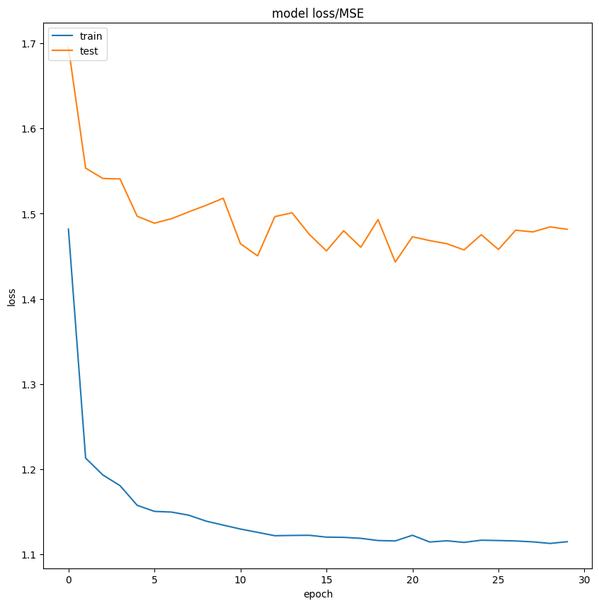

```python
# summarize history for Loss/MSE
fig_acc = plt.figure(figsize=(10, 10))
plt.plot(history.history['loss'])
plt.plot(history.history['val_loss'])
plt.title('model loss/MSE')
plt.ylabel('loss')
plt.xlabel('epoch')
plt.legend(['train', 'test'], loc='upper left')
plt.show()
fig_acc.savefig("LSTM_loss1.png")
```

## Validating our model

Now we need to create our simulated streaming validation set to test our model "in production". With our linear regression models, we were able to begin making predictions with only two datapoints, but the LSTM model requires an input sequence of *seq_length* to make a prediction. We can get around this limitation by "padding" our inputs when they are too short.

**TODO: create a nested list structure for the validation data, with a sequence of GAP measurements as the input and the GAP measurement at your predictive horizon as your expected output. Begin your predictions after only two GAP measurements are available, and check out [this keras function](https://www.tensorflow.org/api_docs/python/tf/keras/utils/pad_sequences) to automatically pad sequences that are too short.**

**Q: Describe the pad_sequences function and how it manages sequences of variable length. What does the "padding" argument determine, and which setting makes the most sense for our use case here?**

A: The pad_sequences function is a utility in Keras/TensorFlow that standardizes sequences of varying lengths into uniform-length sequences. The `pad_sequences` function is a utility in Keras/TensorFlow that standardizes sequences of varying lengths into uniform-length sequences. Here's a breakdown:

### I. **What `pad_sequences` Does**:

1. **Handles Variable-Length Sequences**:
   - a) If sequences are shorter than a specified `maxlen`, it **pads** them with a default value (e.g., `0`).
   - b) If sequences are longer than `maxlen`, it **truncates** them to fit.
2. **Key Parameters**:
   - a) `maxlen`: Forces all sequences to this length.
   - b) `padding`: Determines where to add padding:
     - `'pre'` (default): Adds padding **at the beginning** of sequences.
     - `'post'`: Adds padding **at the end** of sequences.

   -c) `truncating`: Determines where to truncate sequences if they exceed `maxlen`:
   - `'pre'`: Removes values from the **beginning** of sequences.
   - `'post'`: Removes values from the **end** of sequences.
   - d) `value`: The value used for padding (default is `0`).
   - e) `dtype`: Data type of the output (e.g., `float32`).

### II. **Why `padding='pre'` Makes Sense for Time Series (Your Use Case)**:

1. **Preserves Temporal Order**:
   - a) Time series data is sequential, where the **most recent values** are often the most relevant for prediction.
   - b) `padding='pre'` adds zeros to the **beginning** of short sequences, keeping the actual data at the **end**:

     ```
     Example (maxlen=5):
     Original: [0.5, 0.6] → Padded: [0, 0, 0, 0.5, 0.6]
     ```

   - c)This ensures the model sees the most recent data in the same position as during training.
2. **Simulates Real-Time Streaming**:
   - a) When starting predictions with only 2 data points, `padding='pre'` mimics gradually filling the sequence with new data:

     ```
     Step 1: [0, 0, 0, 0.5, 0.6]  # First prediction with 2 values
     Step 2: [0, 0, 0.5, 0.6, 0.55]  # After a new value arrives
     ```

3. **Avoids Misleading the Model**:
   - a) Padding at the end (`'post'`) would place zeros **after** the actual data, which could confuse the model into thinking future values are zeros.

### III. Examples

**A. Eample Without Padding**: If sequences are variable-length:

```
Sequence 1: [0.5, 0.6]
Sequence 2: [0.5, 0.6, 0.55]
```

The LSTM model would crash because it expects fixed-length input.

### B. Example With Padding**:

After `pad_sequences(padding='pre', maxlen=5)`:

[output not shown]

```python
# Create empty lists to store:
# val_arrays: Input sequences (varying lengths initially)
# val_labs: Target values (GAP measurements at ph steps ahead)

val_arrays = []
val_labs = []

# Prepare input sequences and labels for validating an LSTM model.
# It simulates a scenario where we start with minimal data (2 readings) and gradually build up to full-length sequences.

# Create list of GAP readings - sequence starting with a minimum of two readings(since 2 readings needed for a prediction), building up to seq_length
# Start with 2 readings:
# First iteration (i=2): Sequence = [val_0, val_1]
# Next iteration (i=3): Sequence = [val_0, val_1, val_2]
#  And continue ... up to seq_length measurements.
# Label Alignment:
# For each sequence ending at index i, the label is the value at i + ph - 1
# Example: If ph=5, a sequence ending at i=10 predicts the value at index 14.
# Edge Handling:
# Breaks the loop if there’s insufficient data for the label.

for i in range(2, len(val_df['Global_active_power'])):
    # Get all available readings up to current index

    # Collect historical data
    # For each step i, this grabs all readings up to but not including the current position i.
    raw_seq = val_df['Global_active_power'].values[:i]  # Get readings from start to current position

    # Get label (ph steps ahead) - The label is the reading ph steps ahead of the current position.
    # Prediction Target(i=4, ph=3): time's GAP(i=4 + 3 - 1 = 6)
    # Result:
    # val_arrays = [[0.5, 0.6], [0.5, 0.6, 0.55], [0.5, 0.6, 0.55, 0.7]]
    # val_labs = [0.65, 0.75, 0.8] (i=4+3-1 => 6's actual GAP)

    if i + ph - 1 < len(val_df):  # Check if we have enough data for the label
        val_labs.append(val_df['Global_active_power'].values[i + ph - 1])
    else:  # Handle edge case at end of dataset
        break

    val_arrays.append(raw_seq)

# Pad sequences to uniform length (seq_length) with pre-padding (zeros at beginning) to ensure the model gets consistent input
# Forces all sequences to have the same length (seq_length, e.g., 30).
# Short sequences get 0s added at the beginning
val_arrays = pad_sequences(
    val_arrays,
    maxlen=seq_length,  # Force all sequences to be seq_length long
    dtype='float32',     # Match TensorFlow's default dtype
    padding='pre',       # Add zeros at BEGINNING of sequences (preserve recent data)
    truncating='pre',    # Truncate from beginning if sequences are too long (shouldn't happen here)
    value=0              # Use 0 for padding (consider using mean value if better for your data)
)

# Convert labels to numpy array with proper dtype
val_labs = np.array(val_labs, dtype=np.float32)

print("Padded validation sequences shape:", val_arrays.shape)
print("Validation labels shape:", val_labs.shape)

print("First index of val_array", val_arrays[0])
print("val_array",val_arrays)

print("Val_labs", val_labs)
```

```
Padded validation sequences shape: (4093, 30)
Validation labels shape: (4093,)
First index of val_array [0.    0.    0.    0.    0.    0.    0.    0.    0.    0.    0.    0.
 0.    0.    0.    0.    0.    0.    0.    0.    0.    0.    0.    0.
 0.    0.    0.    0.    0.326 1.962]
val_array [[0.    0.    0.    ... 0.    0.326 1.962]
 [0.    0.    0.    ... 0.326 1.962 3.386]
 [0.    0.    0.    ... 1.962 3.386 2.616]
 ...
 [1.406 1.392 1.304 ... 1.266 1.338 1.468]
 [1.392 1.304 1.466 ... 1.338 1.468 1.444]
 [1.304 1.466 1.388 ... 1.468 1.444 1.276]]
Val_labs [2.724 1.94  1.944 ... 1.884 1.694 1.766]
```

We will now run this validation data through our LSTM model and visualize its performance like we did on the linear regression data.

```
Current val_arrays shape: (4093, 30)
Reshaped val_arrays shape: (4093, 30, 1)
Reshaped val_arrays shape: (4093, 30, 1)
Shape of val_labs (4093,)
128/128 - 2s - 17ms/step - loss: 0.8242 - mse: 0.8242

MSE: 0.82420414686203
128/128 ━━━━━━━━━━━━━━━━━━━━ 4s 27ms/step
True Test [2.724 1.94  1.944 ... 1.884 1.694 1.766]
```

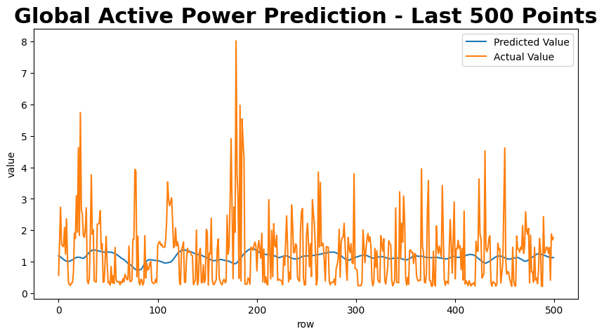

```
Pred_Test [[-0.00713222]
 [ 0.00312395]
 [ 0.02738443]
 ...
 [ 1.1311783 ]
 [ 1.1290383 ]
 [ 1.1306075 ]]
```

```python
print("Current val_arrays shape:", val_arrays.shape)

val_arrays = val_arrays.reshape(val_arrays.shape[0], seq_length, 1)
print("Reshaped val_arrays shape:", val_arrays.shape)

# Reshape validation data
val_arrays = val_arrays.reshape(val_arrays.shape[0], seq_length, 1)
print("Reshaped val_arrays shape:", val_arrays.shape)

# actual GAP values to predict
print("Shape of val_labs", val_labs.shape)

# Firt Test the model by Evaluating the model and get MSE as output
scores_test = model.evaluate(val_arrays, val_labs, verbose=2)
print('\nMSE: {}'.format(scores_test[1]))

#Use a trained machine learning model (model) to predict future Global_active_power (GAP) values.
#Compare these predictions to actual values (val_labs).
#Save the predictions to a CSV file for later analysis.

# Generate predictions - Make predictions of future GAP values pH = 5
y_pred_test = model.predict(val_arrays) #make predictions for the validaton data.
y_true_test = val_labs

# The rest of your code remains the same
test_set = pd.DataFrame(y_pred_test)
test_set.to_csv('submit_test.csv', index = None) # Create a spreadsheet-like table of predictions.

print("True Test", y_true_test)


# Plot the predicted data vs. the actual data
# we will limit our plot to the first 500 predictions for better visualization

fig_verify = plt.figure(figsize=(10, 5))
plt.plot(y_pred_test[-500:], label = 'Predicted Value')
plt.plot(y_true_test[-500:], label = 'Actual Value')
plt.title('Global Active Power Prediction - Last 500 Points', fontsize=22, fontweight='bold')
plt.ylabel('value')
plt.xlabel('row')
plt.legend()
plt.show()
fig_verify.savefig("model_regression_verify.png")

print("Pred_Test", y_pred_test)
```

**Q: How did your model perform? What can you tell about the model from the loss curves? What could we do to try to improve the model?**

Answer:

# I.Evalutation of the model

## B. OBSERATION OF PREDICTED Vs ACTUAL GLOBAL ACTIVE POWER:

### II. LOSS CURVE OF THE MODEL:

A. TRAINING LOSS:

B. VALIDATION/TEST LOSS:

### WHAT COULD BE DONE TO IMPROVE MODEL:

1. Learning Rate Optimization: Try reducing the learning rate (e.g., to 0.001 or 0.0001) and observe the impact on the model's performance. Use techniques like learning rate scheduling or adaptive optimizers to fine-tune the learning rate during training. This might improve the model performance
2. Model Architecture Exploration: Consideration of deeper LSTM networks (more layers) or bidirectional LSTMs to capture more complex temporal dependencies in the data is good. Also addition of one or two 1D convolutional layers before the LSTM layers is another option to try. The CNNs would convolve across the time series, extracting relevant features like daily or weekly patterns.
3. Linear layers could be added after the LSTM layers to further process the learned representations. They can help map the LSTM output to the desired prediction range leading to model improvement.

## Model Optimization

Now it's your turn to build an LSTM-based model in hopes of improving performance on this training set. Changes that you might consider include:

- Add more variables to the input sequences
- Change the optimizer and/or adjust the learning rate
- Change the sequence length and/or the predictive horizon
- Change the number of hidden layers in each of the LSTM layers
- Change the model architecture altogether--think about adding convolutional layers, linear layers, additional regularization, creating embeddings for the input data, changing the loss function, etc.

There isn't any minimum performance increase or number of changes that need to be made, but I want to see that you have tried some different things. Remember that building and optimizing deep learning networks is an art and can be very difficult, so don't make yourself crazy trying to optimize for this assignment.

**Q: What changes are you going to try with your model? Why do you think these changes could improve model performance?**

A: The following are the model changes which I would try next

1. Increasing number of LSTM layers to 5
2. Architectural change - 2 convolutional layer, max pooling layer, Dense(Fully connected) layers and output layer Change sequence_length to 50

3.Adding Multivariate (Voltage, Global Intensity and Global Reactive power) as Dependent variables 4. Architerctural change - CNN feature extraction, Bidirectional LSTM with attention mechanism, Temporal Pooling and output layer

# DESCRIPTIONS OF THE ABOBE PROPOSED MODEL CHANGES:

## 1. Increasing LSTM Layers to 5 (from 2)

# A. Benefits:

Deeper LSTM networks (more layers) can learn hierarchical temporal dependencies. Lower layers might capture short-term patterns (e.g., daily fluctuations), while higher layers learn longer-term patterns (e.g., weekly or seasonal trends).

## B. Why it might improve performance##: Power consumption is influenced by factors at multiple time scales. A deeper LSTM could better capture these complex temporal relationships.

## Caveats:

Increasing layers also increases the risk of overfitting, especially with limited data. Need to check regularization (dropout, L1/L2) and potentially use techniques like early stopping.

## 2. Adding 2 Convolutional Layers, Max Pooling, and Dense Layers##

## A. Benefits:

CNNs for Feature Extraction: Convolutional Neural Networks (CNNs) are excellent at automatically learning local patterns in sequential data. In time series, 1D CNNs can identify relevant features within short time windows (e.g., daily peaks, weekly patterns) before feeding them to the LSTM. This reduces the burden on the LSTM, allowing it to focus on longer-range dependencies. Max Pooling: Reduces the dimensionality of the CNN outputs, making the model more computationally efficient and potentially reducing overfitting. Dense Layers: Fully connected (dense) layers after the LSTM can further process the learned representations before making the final prediction.

## B. Why it might improve performance:

This architecture combines the strengths of CNNs (local feature extraction) and LSTMs (long-range dependencies). It's a powerful approach for time series.

## 3. Changing sequence_length to 50 (from 30):

## A. Benefits:##

A longer sequence length means the model sees more historical data when making predictions. This can be beneficial if there are long-term dependencies in the data (e.g., weekly or monthly cycles).

## B. Why it might improve performance:##

If your power consumption patterns have dependencies that span longer than your original sequence_length, increasing it could allow the model to learn these patterns. Caveats: A longer sequence length increases the computational cost and memory requirements. It also increases the risk of overfitting if the data isn't sufficient.

## 4. Adding Multivariate Inputs (Voltage, Global Intensity, Global Reactive Power)

## A. Benefits:## Power consumption is rarely influenced by active power alone. Including other relevant variables like voltage, intensity, and reactive power provides the model with more information, potentially leading to more accurate predictions.

## B. Why it might improve performance:##

These additional variables likely have a strong relationship with active power. Including them allows the model to learn these relationships and make more informed predictions.

## 5. CNN Feature Extraction, Bidirectional LSTM with Attention, Temporal Pooling

## . Benefits:

## A. Bidirectional LSTM:##

Processes the input sequence in both forward and backward directions, allowing the model to capture dependencies from both past and future (relative to a given time step). This can be useful for identifying patterns that are influenced by both past and future events. Attention Mechanism: Allows the model to focus on the most relevant parts of the input sequence when making predictions. It learns which time steps (or which of the CNN-extracted features) are most important.

## B. Temporal Pooling:## A form of pooling applied to the time dimension.

It can help reduce dimensionality and focus on the most salient temporal features.

## C. Why it might improve performance:##

This is a sophisticated architecture designed to capture complex temporal relationships and focus on the most relevant information. The bidirectional LSTM captures dependencies in both directions, and the attention mechanism helps the model prioritize the most important time steps. Temporal pooling further refines the feature representation.

```python
# I. Changes in Model - Increase number of LSTM layers to 5 from 2
# Play with your ideas for optimization here

# Read the .txt file into a DataFrame
df = pd.read_csv(file_path, parse_dates=['Datetime'])

# Display the first few rows of the DataFrame to verify it loaded correctly
print(df.head())

#create training and validation sets here
# Sort the data by Datetime to ensure it's in chronological order
df = df.sort_values('Datetime')

# Assign size for data subset (1% of the entire dataset)
subset_size = int(0.01 * len(df))

# Take random data subset
#n=subset_size: This argument specifies the number of rows needed in random subset.
#random_state=42: This is crucial for reproducibility.  It sets the seed for the random number generator.
#         Incase this code is run multiple times with the same random_state, this will result in getting the same random subset which is important for testing,
#         debugging, and sharing results.  IF this argument is None, then the same subset is not got every time
df_subset = df.sample(n=subset_size, random_state=42)

# Sort the subset by Datetime again to maintain chronological order
df_subset = df_subset.sort_values('Datetime')

# Split data subset 80/20 for train/validation
# Split the df_subset which is a random sample of the original DataFrame, its index still reflects the original time order into training and validation sets.
# We use the index to split to maintain the time order
#len(df_subset): Gets the number of rows in the df_subset.
#0.8 * len(df_subset): Calculates 80% of the number of rows. This determines the split point between training and validation sets.
#int(...): Converts the result to an integer. This is necessary because slice indices must be integers. This effectively truncates any decimal portion, so the training set might be slightly smaller than 80% if the total number of rows isn't perfectly divisible by 5.
#split_index: Stores the calculated index value. This index marks the boundary between the training and validation sets.

split_index = int(0.8 * len(df_subset))

# This creates the training set. It takes all rows from df_subset up to (but not including) the row at split_index.
# Because the original index from the dataframe is used, and because the subset was randomly selected while maintaining the original time order via the index,
# this subset will maintain the time order.
# train_df: Stores the resulting training DataFrame

train_df = df_subset[:split_index]

# Create the validation set. It takes all rows from df_subset starting from the row at split_index to the end of the DataFrame.
val_df = df_subset[split_index:]


#reset the indices for cleanliness
#After splitting the data, the original index from the full dataset is retained. Resetting the index ensures that both train_df and val_df have a clean, continuous index starting from 0.
#This makes it easier to work with the data, especially when iterating over rows or accessing specific entries by index.
train_df = train_df.reset_index()
val_df = val_df.reset_index()

print(f"Training set shape: {train_df.shape}")
print(f"Validation set shape: {val_df.shape}")

seq_arrays = []
seq_labs = []
import numpy as np

# Get GAP readings from your DataFrame column
gap_readings = train_df['Global_active_power'].values  # Direct numpy array access

#use 30 consecutive measurements to predict value 5 steps in future
seq_length = 30  # 30-minute window
ph = 5           # Predict 5 minutes ahead
feat_cols = ['Global_active_power']  # Define feature columns

# Create sequences with alignment for predictive horizon
seq_arrays = []
seq_labs = []

# Calculate valid range for sequence creation
# Total Data Points: len(gap_readings) = 16,359 historical GAP measurements.
#Sequence Length: Each input sequence uses 30 consecutive measurements.
#Predictive Horizon:  To predict the GAP value 5 steps ahead of the input sequence.
#Input Sequence: Each sequence starts at index i and ends at i + seq_length - 1.
#Output Value: Predicted value is at index i + seq_length + ph - 1.
#Last Valid Sequence:
#Start index i must satisfy:
#i + seq_length + ph - 1 < len(gap_readings)
#For the dataset with len = 16359:
# i + 30 + 5 - 1 < 16,359 → i < 16,359 - 34 → i ≤ 16,324
# Total sequences: 16,325 (i ranges from 0 to 16,324).

num_samples = len(gap_readings) - seq_length - ph + 1

#Sequence creation loop
#Input Sequence: Sliding window of 30 consecutive values
#Output Value: Value 5 steps after the end of the input window

for i in range(num_samples):
    # Input: 30 consecutive GAP measurements
    input_seq = gap_readings[i:i+seq_length]

    # Output: GAP value 5 cycles after sequence end
    output_val = gap_readings[i + seq_length + ph - 1]

    # append(input_seq): adds the current input_seq (which is itself a sequence of data points) to the end of the seq_arrays list.
    # So, seq_arrays will become a list of lists (or a list of arrays).
    #input_seq is a sequence of 30 consecutive GAP measurements (because seq_length = 30).
    #seq_arrays is a list that will contain all these sequences.
    #.append() adds input_seq as a new element to the end of seq_arrays.
    #After this operation, seq_arrays becomes a list of lists, where each inner list is a sequence of 30 GAP measurements.
    # Example:
    # seq_arrays = [
    # [0.5, 0.6, ..., 0.8],  # First sequence (30 values)
    # [0.6, 0.7, ..., 0.9],  # Second sequence (30 values)
    # ...
    seq_arrays.append(input_seq) #store the input sequence of time series data in numpy array

    # add the output_val to the seq_labs list
    # output_val is a single GAP measurement, 5 steps ahead of the end of the input sequence.
    # seq_labs is a list that will contain all these future values.
    # append(): This adds output_val as a new element to the end of seq_labs.
    # After this operation, seq_labs becomes a list of individual GAP values, each corresponding to the future value for its respective input sequence.
    # Example:
    # python
    # seq_labs = [0.7, 0.8, 0.9, ...]  # Each value corresponds to a sequence in seq_arrays
    seq_labs.append(output_val)
```

```python
# Convert to numpy arrays with proper typing
seq_arrays = np.array(seq_arrays, dtype=np.float32).reshape(-1, seq_length, len(feat_cols))
seq_labs = np.array(seq_labs, dtype=np.float32)

print("Input shape:", seq_arrays.shape)
print("Output shape:", seq_labs.shape)

# Verify dimensions with corrected calculation
expected_samples = len(train_df) - seq_length - ph + 1
expected_shape = (expected_samples, seq_length, len(feat_cols))

try:
    assert seq_arrays.shape == expected_shape, (
    f"Sequence array shape mismatch. Got {seq_arrays.shape}, "
    f"expected {expected_shape}. Check data length: {len(train_df)} "
    f"should be ≥ {seq_length + ph}"
)

    assert seq_labs.shape == (expected_samples,), (
    f"Label shape mismatch. Got {seq_labs.shape}, "
    f"expected ({expected_samples},)"

)
    print("All assertions passed!")
except AssertionError as e:
    print(f"Assertion Error: {e}")
    print(f"Required data length: {seq_length + ph - 1}")
    print(f"Actual data length: {len(train_df)}")

assert(seq_arrays.shape == (len(train_df)-seq_length-ph+1,seq_length, len(feat_cols)))
assert(seq_labs.shape == (len(train_df)-seq_length-ph+1,))
# define path to save model
model_path = 'LSTM_model1.keras'

# build the network
# Onfe Feature which is GAP and one Output value (GAP) is predicted
nb_features = 1
nb_out = 1

# Initialize a Sequential model
model = Sequential()

# LSTM Layer 1
# create an LSTM layer with 16 LSTM units (or neurons). These units are the core processing elements of the LSTM, learning temporal dependencies in the input sequence.
# return_sequences=True: This is crucial for stacking LSTM layers. Setting it to True means that this LSTM layer will output a sequence of hidden states for each time step
# in the input sequence. This sequence will then be fed as input to the next LSTM layer.
# nb_features: This is the number of features in your input at each time step (e.g., 1 if you're only using 'Global_active_power').
# Only the first LSTM layer needs to have this explicit input_shape defined. Subsequent LSTM layers will infer the input shape from the output of the previous layer.
model.add(Input(shape=(seq_length, nb_features)))  # Input layer FIRST
model.add(LSTM(16, return_sequences=True))  # THEN the LSTM layer

# model.add(Dropout(0.3)) This adds a dropout layer after the LSTM layer. Dropout is a regularization technique that helps prevent overfitting. During training,
# it randomly sets a fraction (in this case, 30% or 0.3) of the input units to 0 at each update. This forces the network to learn more robust features that are not
# reliant on specific combinations of neurons
model.add(Dropout(0.3))

# Layer 2
model.add(LSTM(32, return_sequences=True))
model.add(Dropout(0.3))

# Layer 3
model.add(LSTM(64, return_sequences=True))
model.add(Dropout(0.3))

# Layer 4
model.add(LSTM(32, return_sequences=True))
model.add(Dropout(0.3))

# Layer 5 (Final LSTM)
model.add(LSTM(16, return_sequences=False))
model.add(Dropout(0.3))

# Add Dense (fully connected) output layer
model.add(Dense(units=nb_out))  # Output layer with 1 unit for regression
model.add(Activation("linear"))  # Linear activation for regression

# Define optimizer with learning rate
# Use lower learning rate for deeper network

optimizer = keras.optimizers.Adam(learning_rate=0.001)
model.compile(loss='mean_squared_error', optimizer=optimizer, metrics=['mse'])

#Loss function is MSE, Adam optimizer, track MSE durig trainig
# uses Mean Squared Error as both the loss function and a metric, appropriate for regression tasks.
model.compile(loss='mean_squared_error', optimizer=optimizer, metrics=['mse'])

print(model.summary())

# fit the network (train it)
# max number of trainig epochs = 100
# number of samples per gradient update (batch size) = 500
# use 5% of data for validation
# verbosity mode = 2, one line per epoch
# callback - early stopping to prevent overfitting and if no more learnig is happening
#  monitor='val_loss',  # Monitor validation loss
# min_delta=0:  Minimum change to qualify as improvement
# patience=10:  Number of epochs with no improvement after which training will stop
# verbose=0:  Verbosity mode
# mode='min'  # The direction is automatically inferred if not set

# Model checkpoint to save best model
# model_path,  # Path to save the model
# monitor='val_loss',  # Monitor validation loss
# save_best_only=True,  # Only save when the model is better than the previous best
# mode='min',  # Lower validation loss is better
#verbose=0  # Verbosity mode

history = model.fit(seq_arrays, seq_labs, epochs=100, batch_size=500, validation_split=0.05, verbose=2,
          callbacks = [keras.callbacks.EarlyStopping(monitor='val_loss', min_delta=0, patience=10, verbose=0, mode='min'),
                       keras.callbacks.ModelCheckpoint(model_path,monitor='val_loss', save_best_only=True, mode='min', verbose=0)]
          )

# list all data in history
# After training, it prints the keys of the history object, which typically include 'loss', 'mse', 'val_loss', and 'val_mse', representing the training and validation metrics over epochs.
print(history.history.keys())

# show me how one or two of your different models perform
# using the code from the "Validating our model" section above
val_arrays = []
val_labs = []

# Create sequences starting with minimum of 2 readings, building up to seq_length
for i in range(2, len(val_df['Global_active_power'])):
    # Get all available readings up to current index
    raw_seq = val_df['Global_active_power'].values[:i]  # Get readings from start to current position

    # Get label (ph steps ahead)
    if i + ph - 1 < len(val_df):  # Check if we have enough data for the label
        val_labs.append(val_df['Global_active_power'].values[i + ph - 1])
    else:  # Handle edge case at end of dataset
        break

    val_arrays.append(raw_seq)

# Pad sequences to uniform length (seq_length) with pre-padding (zeros at beginning)
val_arrays = pad_sequences(
    val_arrays,
    maxlen=seq_length,  # Force all sequences to be seq_length long
    dtype='float32',     # Match TensorFlow's default dtype
    padding='pre',       # Add zeros at BEGINNING of sequences (preserve recent data)
    truncating='pre',    # Truncate from beginning if sequences are too long (shouldn't happen here)
    value=0              # Use 0 for padding (consider using mean value if better for your data)
)
```

```
   Unnamed: 0        Date      Time  Global_active_power  \
0           0  2006-12-16  17:24:00                4.216
1           1  2006-12-16  17:25:00                5.360
2           2  2006-12-16  17:26:00                5.374
3           3  2006-12-16  17:27:00                5.388
4           4  2006-12-16  17:28:00                3.666

   Global_reactive_power  Voltage  Global_intensity  Sub_metering_1  \
0                  0.418   234.84              18.4             0.0
1                  0.436   233.63              23.0             0.0
2                  0.498   233.29              23.0             0.0
3                  0.502   233.74              23.0             0.0
4                  0.528   235.68              15.8             0.0

   Sub_metering_2  Sub_metering_3            Datetime  gap_monthly  \
0             1.0            17.0 2006-12-16 17:24:00          NaN
1             1.0            16.0 2006-12-16 17:25:00          NaN
2             2.0            17.0 2006-12-16 17:26:00          NaN
3             1.0            17.0 2006-12-16 17:27:00          NaN
4             1.0            17.0 2006-12-16 17:28:00          NaN

   grp_monthly  v_monthly  gi_monthly
0          NaN        NaN         NaN
1          NaN        NaN         NaN
2          NaN        NaN         NaN
3          NaN        NaN         NaN
4          NaN        NaN         NaN
Training set shape: (16393, 16)
Validation set shape: (4099, 16)
Input shape: (16359, 30, 1)
Output shape: (16359,)
All assertions passed!
```

```
Model: "sequential_25"
```

```
┏━━━━━━━━━━━━━━━━━━━━━━━━━━━━━━━━━━━━━━┳━━━━━━━━━━━━━━━━━━━━━━━━━━━━━┳━━━━━━━━━━━━━━━━━┓
┃ Layer (type)                         ┃ Output Shape                ┃         Param # ┃
┡━━━━━━━━━━━━━━━━━━━━━━━━━━━━━━━━━━━━━━╇━━━━━━━━━━━━━━━━━━━━━━━━━━━━━╇━━━━━━━━━━━━━━━━━┩
│ lstm_39 (LSTM)                       │ (None, 30, 16)              │           1,152 │
├──────────────────────────────────────┼─────────────────────────────┼─────────────────┤
│ dropout_52 (Dropout)                 │ (None, 30, 16)              │               0 │
├──────────────────────────────────────┼─────────────────────────────┼─────────────────┤
│ lstm_40 (LSTM)                       │ (None, 30, 32)              │           6,272 │
├──────────────────────────────────────┼─────────────────────────────┼─────────────────┤
│ dropout_53 (Dropout)                 │ (None, 30, 32)              │               0 │
├──────────────────────────────────────┼─────────────────────────────┼─────────────────┤
│ lstm_41 (LSTM)                       │ (None, 30, 64)              │          24,832 │
├──────────────────────────────────────┼─────────────────────────────┼─────────────────┤
│ dropout_54 (Dropout)                 │ (None, 30, 64)              │               0 │
├──────────────────────────────────────┼─────────────────────────────┼─────────────────┤
│ lstm_42 (LSTM)                       │ (None, 30, 32)              │          12,416 │
├──────────────────────────────────────┼─────────────────────────────┼─────────────────┤
│ dropout_55 (Dropout)                 │ (None, 30, 32)              │               0 │
├──────────────────────────────────────┼─────────────────────────────┼─────────────────┤
│ lstm_43 (LSTM)                       │ (None, 16)                  │           3,136 │
├──────────────────────────────────────┼─────────────────────────────┼─────────────────┤
│ dropout_56 (Dropout)                 │ (None, 16)                  │               0 │
├──────────────────────────────────────┼─────────────────────────────┼─────────────────┤
│ dense_24 (Dense)                     │ (None, 1)                   │              17 │
├──────────────────────────────────────┼─────────────────────────────┼─────────────────┤
│ activation_10 (Activation)           │ (None, 1)                   │               0 │
└──────────────────────────────────────┴─────────────────────────────┴─────────────────┘
```

```
 Total params: 47,825 (186.82 KB)
```

```
 Trainable params: 47,825 (186.82 KB)
```

```
 Non-trainable params: 0 (0.00 B)
```

```
None
32/32 - 19s - 584ms/step - loss: 1.3930 - mse: 1.3930 - val_loss: 1.6131 - val_mse: 1.6131
32/32 - 11s - 329ms/step - loss: 1.1732 - mse: 1.1732 - val_loss: 1.4805 - val_mse: 1.4805
32/32 - 11s - 331ms/step - loss: 1.1562 - mse: 1.1562 - val_loss: 1.5127 - val_mse: 1.5127
32/32 - 9s - 268ms/step - loss: 1.1659 - mse: 1.1659 - val_loss: 1.4882 - val_mse: 1.4882
32/32 - 10s - 307ms/step - loss: 1.1500 - mse: 1.1500 - val_loss: 1.5051 - val_mse: 1.5051
32/32 - 12s - 379ms/step - loss: 1.1518 - mse: 1.1518 - val_loss: 1.4719 - val_mse: 1.4719
32/32 - 10s - 327ms/step - loss: 1.1522 - mse: 1.1522 - val_loss: 1.4609 - val_mse: 1.4609
32/32 - 8s - 248ms/step - loss: 1.1486 - mse: 1.1486 - val_loss: 1.4690 - val_mse: 1.4690
32/32 - 12s - 373ms/step - loss: 1.1509 - mse: 1.1509 - val_loss: 1.4423 - val_mse: 1.4423
32/32 - 10s - 306ms/step - loss: 1.1504 - mse: 1.1504 - val_loss: 1.4784 - val_mse: 1.4784
32/32 - 8s - 246ms/step - loss: 1.1504 - mse: 1.1504 - val_loss: 1.4793 - val_mse: 1.4793
32/32 - 11s - 358ms/step - loss: 1.1451 - mse: 1.1451 - val_loss: 1.4859 - val_mse: 1.4859
32/32 - 10s - 307ms/step - loss: 1.1412 - mse: 1.1412 - val_loss: 1.4873 - val_mse: 1.4873
32/32 - 8s - 257ms/step - loss: 1.1452 - mse: 1.1452 - val_loss: 1.4766 - val_mse: 1.4766
32/32 - 11s - 354ms/step - loss: 1.1456 - mse: 1.1456 - val_loss: 1.4658 - val_mse: 1.4658
32/32 - 11s - 354ms/step - loss: 1.1433 - mse: 1.1433 - val_loss: 1.5017 - val_mse: 1.5017
32/32 - 8s - 249ms/step - loss: 1.1336 - mse: 1.1336 - val_loss: 1.4587 - val_mse: 1.4587
32/32 - 10s - 319ms/step - loss: 1.1368 - mse: 1.1368 - val_loss: 1.4770 - val_mse: 1.4770
32/32 - 12s - 377ms/step - loss: 1.1441 - mse: 1.1441 - val_loss: 1.5097 - val_mse: 1.5097
dict_keys(['loss', 'mse', 'val_loss', 'val_mse'])
Padded validation sequences shape: (4093, 30)
Validation labels shape: (4093,)
Shape of val_arrays: (4093, 30, 1)
Shape of val_labs: (4093,)
128/128 - 2s - 15ms/step - loss: 0.8229 - mse: 0.8229

MSE: 0.8229178786277771
128/128 ━━━━━━━━━━━━━━━━━━━━ 4s 26ms/step
```

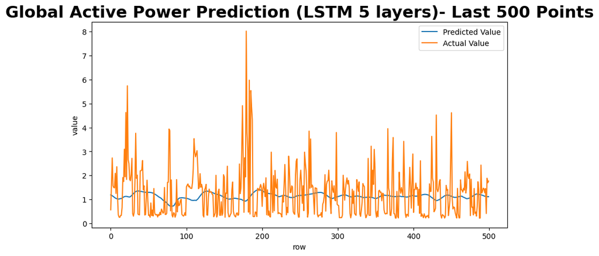

```python
# Convert labels to numpy array with proper dtype
val_labs = np.array(val_labs, dtype=np.float32)

print("Padded validation sequences shape:", val_arrays.shape)
print("Validation labels shape:", val_labs.shape)

# Reshape val_arrays to add the feature dimension
val_arrays = np.reshape(val_arrays, (val_arrays.shape[0], val_arrays.shape[1], nb_features))

# Ensure val_labs is a 1D array
val_labs = np.reshape(val_labs, (-1,))

# Debugging: Print shapes
print("Shape of val_arrays:", val_arrays.shape)
print("Shape of val_labs:", val_labs.shape)

# Evaluate the model
scores_test = model.evaluate(val_arrays, val_labs, verbose=2)
print('\nMSE: {}'.format(scores_test[1]))

# Make predictions
y_pred_test = model.predict(val_arrays)
y_true_test = val_labs

# Save predictions to CSV
test_set = pd.DataFrame(y_pred_test)
test_set.to_csv('submit_test.csv', index=None)

# Plot the predicted data vs. the actual data
fig_verify = plt.figure(figsize=(10, 5))
plt.plot(y_pred_test[-500:], label='Predicted Value')
plt.plot(y_true_test[-500:], label='Actual Value')
plt.title('Global Active Power Prediction (LSTM 5 layers)- Last 500 Points', fontsize=22, fontweight='bold')
plt.ylabel('value')
plt.xlabel('row')
plt.legend()
plt.show()
fig_verify.savefig("model_regression_verify.png")
```

```python
# II. Architectural change - 2 convolutional layer, max pooling layer, Dense(Fully connected) layersand output layer
# Play with your ideas for optimization here

# Read the .txt file into a DataFrame
df = pd.read_csv(file_path, parse_dates=['Datetime'])

# Display the first few rows of the DataFrame to verify it loaded correctly
print(df.head())

#create training and validation sets here
# Sort the data by Datetime to ensure it's in chronological order
df = df.sort_values('Datetime')

# Assign size for data subset (1% of the entire dataset)
subset_size = int(0.01 * len(df))

# Take random data subset
#n=subset_size: This argument specifies the number of rows needed in random subset.
#random_state=42: This is crucial for reproducibility.  It sets the seed for the random number generator.
#         Incase this code is run multiple times with the same random_state, this will result in getting the same random subset which is important for testing,
#         debugging, and sharing results.  IF this argument is None, then the same subset is not got every time
df_subset = df.sample(n=subset_size, random_state=42)

# Sort the subset by Datetime again to maintain chronological order
df_subset = df_subset.sort_values('Datetime')

# Split data subset 80/20 for train/validation
# Split the df_subset which is a random sample of the original DataFrame, its index still reflects the original time order into training and validation sets.
# We use the index to split to maintain the time order
#len(df_subset): Gets the number of rows in the df_subset.
#0.8 * len(df_subset): Calculates 80% of the number of rows. This determines the split point between training and validation sets.
#int(...): Converts the result to an integer. This is necessary because slice indices must be integers. This effectively truncates any decimal portion, so the training set might be slightly smaller than 80% if the total number of rows isn't perfectly divisible by 5.
#split_index: Stores the calculated index value. This index marks the boundary between the training and validation sets.
split_index = int(0.8 * len(df_subset))

# This creates the training set. It takes all rows from df_subset up to (but not including) the row at split_index.
# Because the original index from the dataframe is used, and because the subset was randomly selected while maintaining the original time order via the index,
# this subset will maintain the time order.
# train_df: Stores the resulting training DataFrame
train_df = df_subset[:split_index]

# Create the validation set. It takes all rows from df_subset starting from the row at split_index to the end of the DataFrame.
val_df = df_subset[split_index:]

#reset the indices for cleanliness
#After splitting the data, the original index from the full dataset is retained. Resetting the index ensures that both train_df and val_df have a clean, continuous index starting from 0.
#This makes it easier to work with the data, especially when iterating over rows or accessing specific entries by index.
train_df = train_df.reset_index()
val_df = val_df.reset_index()

print(f"Training set shape: {train_df.shape}")
print(f"Validation set shape: {val_df.shape}")


seq_arrays = []
seq_labs = []

# Get GAP readings from your DataFrame column
gap_readings = train_df['Global_active_power'].values  # Direct numpy array access

#use 30 consecutive measurements to predict value 5 steps in future
seq_length = 30  # 30-minute window
ph = 5           # Predict 5 minutes ahead
feat_cols = ['Global_active_power']  # Define feature columns

# Create sequences with alignment for predictive horizon
seq_arrays = []
seq_labs = []

# Calculate valid range for sequence creation

# Total Data Points: len(gap_readings) = 16,359 historical GAP measurements.
#Sequence Length: Each input sequence uses 30 consecutive measurements.
#Predictive Horizon:  To predict the GAP value 5 steps ahead of the input sequence.
#Input Sequence: Each sequence starts at index i and ends at i + seq_length - 1.
#Output Value: Predicted value is at index i + seq_length + ph - 1.
#Last Valid Sequence:
#Start index i must satisfy:
#i + seq_length + ph - 1 < len(gap_readings)
#For the dataset with len = 16359:
# i + 30 + 5 - 1 < 16,359 → i < 16,359 - 34 → i ≤ 16,324
# Total sequences: 16,325 (i ranges from 0 to 16,324).

num_samples = len(gap_readings) - seq_length - ph + 1

#Sequence creation loop
#Input Sequence: Sliding window of 30 consecutive values
#Output Value: Value 5 steps after the end of the input window

for i in range(num_samples):
    # Input: 30 consecutive GAP measurements
    input_seq = gap_readings[i:i+seq_length]

    # Output: GAP value 5 cycles after sequence end
    output_val = gap_readings[i + seq_length + ph - 1]

    # append(input_seq): adds the current input_seq (which is itself a sequence of data points) to the end of the seq_arrays list.
    # So, seq_arrays will become a list of lists (or a list of arrays).
    #input_seq is a sequence of 30 consecutive GAP measurements (because seq_length = 30).
    #seq_arrays is a list that will contain all these sequences.
    #.append() adds input_seq as a new element to the end of seq_arrays.
    #After this operation, seq_arrays becomes a list of lists, where each inner list is a sequence of 30 GAP measurements.
    # Example:
    # seq_arrays = [
    # [0.5, 0.6, ..., 0.8],  # First sequence (30 values)
    # [0.6, 0.7, ..., 0.9],  # Second sequence (30 values)
    # ...
    seq_arrays.append(input_seq) #store the input sequence of time series data in numpy array

    # add the output_val to the seq_labs list
    # output_val is a single GAP measurement, 5 steps ahead of the end of the input sequence.
    # seq_labs is a list that will contain all these future values.
    # append(): This adds output_val as a new element to the end of seq_labs.
    # After this operation, seq_labs becomes a list of individual GAP values, each corresponding to the future value for its respective input sequence.
    # Example:
    # python
    # seq_labs = [0.7, 0.8, 0.9, ...]  # Each value corresponds to a sequence in seq_arrays
    seq_labs.append(output_val)
```

```python
# Convert to numpy arrays with proper typing
seq_arrays = np.array(seq_arrays, dtype=np.float32).reshape(-1, seq_length, len(feat_cols))
seq_labs = np.array(seq_labs, dtype=np.float32)

print("Input shape:", seq_arrays.shape)
print("Output shape:", seq_labs.shape)

# Verify dimensions with corrected calculation
expected_samples = len(train_df) - seq_length - ph + 1
expected_shape = (expected_samples, seq_length, len(feat_cols))

try:
    assert seq_arrays.shape == expected_shape, (
    f"Sequence array shape mismatch. Got {seq_arrays.shape}, "
    f"expected {expected_shape}. Check data length: {len(train_df)} "
    f"should be ≥ {seq_length + ph}"
)

    assert seq_labs.shape == (expected_samples,), (
    f"Label shape mismatch. Got {seq_labs.shape}, "
    f"expected ({expected_samples},)"

)
    print("All assertions passed!")
except AssertionError as e:
    print(f"Assertion Error: {e}")
    print(f"Required data length: {seq_length + ph - 1}")
    print(f"Actual data length: {len(train_df)}")

assert(seq_arrays.shape == (len(train_df)-seq_length-ph+1,seq_length, len(feat_cols)))
assert(seq_labs.shape == (len(train_df)-seq_length-ph+1,))
# define path to save model
model_path = 'LSTM_model1.keras'

# build the network
# Onfe Feature which is GAP and one Output value (GAP) is predicted
nb_features = 1
nb_out = 1

# Initialize a Sequential model
model = Sequential()

# Input shape: (seq_length, nb_features)
input_shape = (seq_length, nb_features)

# 1D Convolutional Layer
inputs = Input(shape=input_shape)
x = Conv1D(filters=64, kernel_size=3, activation='relu')(inputs)

model.add(MaxPooling1D(pool_size=2))  # Downsample the output
model.add(BatchNormalization())  # Normalize the activations
model.add(Dropout(0.3))  # Regularization

# Second 1D Convolutional Layer
model.add(Conv1D(filters=128, kernel_size=3, activation='relu'))
model.add(MaxPooling1D(pool_size=2))
model.add(BatchNormalization())
model.add(Dropout(0.3))

# Global Max Pooling to reduce sequence dimension
model.add(GlobalMaxPooling1D())  # Output shape: (batch_size, 128)

# Dense (Fully Connected) Layers
model.add(Dense(units=64, activation='relu'))
model.add(BatchNormalization())
model.add(Dropout(0.3))

model.add(Dense(units=32, activation='relu'))
model.add(BatchNormalization())
model.add(Dropout(0.3))

# Output Layer
model.add(Dense(units=nb_out, activation='linear'))  # Linear activation for regression

# Compile the model with Huber loss
optimizer = Adam(learning_rate=0.001)
model.compile(loss=Huber(), optimizer=optimizer, metrics=['mse'])

# Print model summary
print(model.summary())

# fit the network (train it)
# max number of trainig epochs = 100
# number of samples per gradient update (batch size) = 500
# use 5% of data for validation
# verbosity mode = 2, one line per epoch
# callback - early stopping to prevent overfitting and if no more learnig is happening
#  monitor='val_loss',  # Monitor validation loss
# min_delta=0:  Minimum change to qualify as improvement
# patience=10:  Number of epochs with no improvement after which training will stop
# verbose=0:  Verbosity mode
# mode='min'  # The direction is automatically inferred if not set

# Model checkpoint to save best model
# model_path,  # Path to save the model
# monitor='val_loss',  # Monitor validation loss
# save_best_only=True,  # Only save when the model is better than the previous best
# mode='min',  # Lower validation loss is better
#verbose=0  # Verbosity mode


history = model.fit(
    seq_arrays,  # Input sequences
    seq_labs,    # Output labels
    epochs=100,
    batch_size=500,
    validation_split=0.05,
    verbose=2,
    callbacks=[
        keras.callbacks.EarlyStopping(monitor='val_loss', patience=10, mode='min', restore_best_weights=True),
        keras.callbacks.ModelCheckpoint(model_path, monitor='val_loss', save_best_only=True, mode='min')
    ]
)


# list all data in history
# After training, it prints the keys of the history object, which typically include 'loss', 'mse', 'val_loss', and 'val_mse', representing the training and validation metrics over epochs.
print(history.history.keys())


# show me how one or two of your different models perform
# using the code from the "Validating our model" section above
val_arrays = []
val_labs = []

# Create sequences starting with minimum of 2 readings, building up to seq_length
for i in range(2, len(val_df['Global_active_power'])):
    # Get all available readings up to current index
    raw_seq = val_df['Global_active_power'].values[:i]  # Get readings from start to current position

    # Get label (ph steps ahead)
    if i + ph - 1 < len(val_df):  # Check if we have enough data for the label
        val_labs.append(val_df['Global_active_power'].values[i + ph - 1])
    else:  # Handle edge case at end of dataset
        break

    val_arrays.append(raw_seq)

# Pad sequences to uniform length (seq_length) with pre-padding (zeros at beginning)
val_arrays = pad_sequences(
    val_arrays,
    maxlen=seq_length,  # Force all sequences to be seq_length long
    dtype='float32',     # Match TensorFlow's default dtype
    padding='pre',       # Add zeros at BEGINNING of sequences (preserve recent data)
    truncating='pre',    # Truncate from beginning if sequences are too long (shouldn't happen here)
    value=0              # Use 0 for padding (consider using mean value if better for your data)
)

# Convert labels to numpy array with proper dtype
val_labs = np.array(val_labs, dtype=np.float32)

print("Padded validation sequences shape:", val_arrays.shape)
print("Validation labels shape:", val_labs.shape)

# Reshape val_arrays to add the feature dimension
val_arrays = np.reshape(val_arrays, (val_arrays.shape[0], val_arrays.shape[1], nb_features))

# Ensure val_labs is a 1D array
val_labs = np.reshape(val_labs, (-1,))

# Debugging: Print shapes
print("Shape of val_arrays:", val_arrays.shape)
print("Shape of val_labs:", val_labs.shape)

# Evaluate the model
scores_test = model.evaluate(val_arrays, val_labs, verbose=2)
print(f'\nValidation Loss (Huber): {scores_test[0]}')
print('\nMSE: {}'.format(scores_test[1]))
```

```
   Unnamed: 0        Date      Time  Global_active_power  \
0           0  2006-12-16  17:24:00                4.216
1           1  2006-12-16  17:25:00                5.360
2           2  2006-12-16  17:26:00                5.374
3           3  2006-12-16  17:27:00                5.388
4           4  2006-12-16  17:28:00                3.666

   Global_reactive_power  Voltage  Global_intensity  Sub_metering_1  \
0                  0.418   234.84              18.4             0.0
1                  0.436   233.63              23.0             0.0
2                  0.498   233.29              23.0             0.0
3                  0.502   233.74              23.0             0.0
4                  0.528   235.68              15.8             0.0

   Sub_metering_2  Sub_metering_3            Datetime  gap_monthly  \
0             1.0            17.0 2006-12-16 17:24:00          NaN
1             1.0            16.0 2006-12-16 17:25:00          NaN
2             2.0            17.0 2006-12-16 17:26:00          NaN
3             1.0            17.0 2006-12-16 17:27:00          NaN
4             1.0            17.0 2006-12-16 17:28:00          NaN

   grp_monthly  v_monthly  gi_monthly
0          NaN        NaN         NaN
1          NaN        NaN         NaN
2          NaN        NaN         NaN
3          NaN        NaN         NaN
4          NaN        NaN         NaN
Training set shape: (16393, 16)
Validation set shape: (4099, 16)
Input shape: (16359, 30, 1)
Output shape: (16359,)
All assertions passed!
```

```
Model: "sequential_26"
```

```
┏━━━━━━━━━━━━━━━━━━━━━━━━━━━━━━━━━━━━━━┳━━━━━━━━━━━━━━━━━━━━━━━━━━━━━┳━━━━━━━━━━━━━━━━━┓
┃ Layer (type)                         ┃ Output Shape                ┃         Param # ┃
┡━━━━━━━━━━━━━━━━━━━━━━━━━━━━━━━━━━━━━━╇━━━━━━━━━━━━━━━━━━━━━━━━━━━━━╇━━━━━━━━━━━━━━━━━┩
│ max_pooling1d_8 (MaxPooling1D)       │ ?                           │               0 │
├──────────────────────────────────────┼─────────────────────────────┼─────────────────┤
│ batch_normalization_16               │ ?                           │     0 (unbuilt) │
│ (BatchNormalization)                 │                             │                 │
├──────────────────────────────────────┼─────────────────────────────┼─────────────────┤
│ dropout_57 (Dropout)                 │ ?                           │               0 │
├──────────────────────────────────────┼─────────────────────────────┼─────────────────┤
│ conv1d_9 (Conv1D)                    │ ?                           │     0 (unbuilt) │
├──────────────────────────────────────┼─────────────────────────────┼─────────────────┤
│ max_pooling1d_9 (MaxPooling1D)       │ ?                           │               0 │
├──────────────────────────────────────┼─────────────────────────────┼─────────────────┤
│ batch_normalization_17               │ ?                           │     0 (unbuilt) │
│ (BatchNormalization)                 │                             │                 │
├──────────────────────────────────────┼─────────────────────────────┼─────────────────┤
│ dropout_58 (Dropout)                 │ ?                           │               0 │
├──────────────────────────────────────┼─────────────────────────────┼─────────────────┤
│ global_max_pooling1d_4               │ ?                           │               0 │
│ (GlobalMaxPooling1D)                 │                             │                 │
├──────────────────────────────────────┼─────────────────────────────┼─────────────────┤
│ dense_25 (Dense)                     │ ?                           │     0 (unbuilt) │
├──────────────────────────────────────┼─────────────────────────────┼─────────────────┤
│ batch_normalization_18               │ ?                           │     0 (unbuilt) │
│ (BatchNormalization)                 │                             │                 │
├──────────────────────────────────────┼─────────────────────────────┼─────────────────┤
│ dropout_59 (Dropout)                 │ ?                           │               0 │
├──────────────────────────────────────┼─────────────────────────────┼─────────────────┤
│ dense_26 (Dense)                     │ ?                           │     0 (unbuilt) │
├──────────────────────────────────────┼─────────────────────────────┼─────────────────┤
│ batch_normalization_19               │ ?                           │     0 (unbuilt) │
│ (BatchNormalization)                 │                             │                 │
├──────────────────────────────────────┼─────────────────────────────┼─────────────────┤
│ dropout_60 (Dropout)                 │ ?                           │               0 │
├──────────────────────────────────────┼─────────────────────────────┼─────────────────┤
│ dense_27 (Dense)                     │ ?                           │     0 (unbuilt) │
└──────────────────────────────────────┴─────────────────────────────┴─────────────────┘
```

```
 Total params: 0 (0.00 B)
```

```
 Trainable params: 0 (0.00 B)
```

```
 Non-trainable params: 0 (0.00 B)
```

```
None
32/32 - 7s - 230ms/step - loss: 1.0315 - mse: 3.8379 - val_loss: 0.8666 - val_mse: 2.8935
32/32 - 1s - 28ms/step - loss: 0.7682 - mse: 2.5771 - val_loss: 0.7452 - val_mse: 2.4550
32/32 - 1s - 39ms/step - loss: 0.6503 - mse: 2.1043 - val_loss: 0.6827 - val_mse: 2.2282
32/32 - 2s - 50ms/step - loss: 0.5915 - mse: 1.8721 - val_loss: 0.6328 - val_mse: 2.0455
32/32 - 1s - 44ms/step - loss: 0.5519 - mse: 1.7321 - val_loss: 0.5826 - val_mse: 1.8585
32/32 - 2s - 67ms/step - loss: 0.5201 - mse: 1.6188 - val_loss: 0.5584 - val_mse: 1.7613
32/32 - 1s - 25ms/step - loss: 0.5002 - mse: 1.5368 - val_loss: 0.5756 - val_mse: 1.8331
32/32 - 1s - 27ms/step - loss: 0.4887 - mse: 1.4897 - val_loss: 0.5576 - val_mse: 1.7608
32/32 - 1s - 39ms/step - loss: 0.4768 - mse: 1.4454 - val_loss: 0.5566 - val_mse: 1.7559
32/32 - 1s - 27ms/step - loss: 0.4614 - mse: 1.3846 - val_loss: 0.5532 - val_mse: 1.7415
32/32 - 1s - 39ms/step - loss: 0.4546 - mse: 1.3683 - val_loss: 0.5516 - val_mse: 1.7329
32/32 - 1s - 27ms/step - loss: 0.4463 - mse: 1.3285 - val_loss: 0.5411 - val_mse: 1.6883
32/32 - 1s - 37ms/step - loss: 0.4438 - mse: 1.3183 - val_loss: 0.5432 - val_mse: 1.6985
32/32 - 1s - 41ms/step - loss: 0.4391 - mse: 1.3089 - val_loss: 0.5433 - val_mse: 1.6988
32/32 - 1s - 44ms/step - loss: 0.4330 - mse: 1.2946 - val_loss: 0.5440 - val_mse: 1.7024
32/32 - 2s - 52ms/step - loss: 0.4299 - mse: 1.2857 - val_loss: 0.5395 - val_mse: 1.6838
32/32 - 2s - 68ms/step - loss: 0.4304 - mse: 1.2763 - val_loss: 0.5386 - val_mse: 1.6789
32/32 - 1s - 34ms/step - loss: 0.4267 - mse: 1.2672 - val_loss: 0.5354 - val_mse: 1.6652
32/32 - 1s - 38ms/step - loss: 0.4230 - mse: 1.2585 - val_loss: 0.5355 - val_mse: 1.6671
32/32 - 2s - 55ms/step - loss: 0.4208 - mse: 1.2509 - val_loss: 0.5356 - val_mse: 1.6673
32/32 - 3s - 80ms/step - loss: 0.4179 - mse: 1.2378 - val_loss: 0.5361 - val_mse: 1.6695
32/32 - 2s - 64ms/step - loss: 0.4152 - mse: 1.2322 - val_loss: 0.5355 - val_mse: 1.6658
32/32 - 1s - 30ms/step - loss: 0.4156 - mse: 1.2309 - val_loss: 0.5340 - val_mse: 1.6593
32/32 - 2s - 51ms/step - loss: 0.4145 - mse: 1.2289 - val_loss: 0.5319 - val_mse: 1.6486
32/32 - 2s - 67ms/step - loss: 0.4115 - mse: 1.2200 - val_loss: 0.5338 - val_mse: 1.6571
32/32 - 1s - 34ms/step - loss: 0.4089 - mse: 1.2094 - val_loss: 0.5326 - val_mse: 1.6530
32/32 - 2s - 51ms/step - loss: 0.4101 - mse: 1.2122 - val_loss: 0.5301 - val_mse: 1.6406
32/32 - 1s - 36ms/step - loss: 0.4088 - mse: 1.2071 - val_loss: 0.5303 - val_mse: 1.6427
32/32 - 1s - 31ms/step - loss: 0.4064 - mse: 1.2058 - val_loss: 0.5317 - val_mse: 1.6490
32/32 - 1s - 38ms/step - loss: 0.4061 - mse: 1.1976 - val_loss: 0.5310 - val_mse: 1.6460
32/32 - 1s - 26ms/step - loss: 0.4053 - mse: 1.1987 - val_loss: 0.5288 - val_mse: 1.6353
32/32 - 1s - 39ms/step - loss: 0.4070 - mse: 1.2020 - val_loss: 0.5302 - val_mse: 1.6420
32/32 - 1s - 28ms/step - loss: 0.4047 - mse: 1.1936 - val_loss: 0.5275 - val_mse: 1.6291
32/32 - 2s - 51ms/step - loss: 0.4046 - mse: 1.1872 - val_loss: 0.5276 - val_mse: 1.6287
32/32 - 3s - 83ms/step - loss: 0.4040 - mse: 1.1941 - val_loss: 0.5301 - val_mse: 1.6413
32/32 - 1s - 30ms/step - loss: 0.4031 - mse: 1.1910 - val_loss: 0.5282 - val_mse: 1.6322
32/32 - 1s - 35ms/step - loss: 0.4023 - mse: 1.1890 - val_loss: 0.5281 - val_mse: 1.6312
32/32 - 1s - 40ms/step - loss: 0.4024 - mse: 1.1889 - val_loss: 0.5291 - val_mse: 1.6351
32/32 - 1s - 42ms/step - loss: 0.4009 - mse: 1.1821 - val_loss: 0.5267 - val_mse: 1.6235
```

[output cut: 19 more lines]

```
32/32 - 1s - 39ms/step - loss: 0.3965 - mse: 1.1616 - val_loss: 0.5259 - val_mse: 1.6226
32/32 - 1s - 24ms/step - loss: 0.3956 - mse: 1.1681 - val_loss: 0.5230 - val_mse: 1.6080
32/32 - 1s - 40ms/step - loss: 0.3973 - mse: 1.1637 - val_loss: 0.5271 - val_mse: 1.6285
32/32 - 1s - 24ms/step - loss: 0.3974 - mse: 1.1687 - val_loss: 0.5281 - val_mse: 1.6332
dict_keys(['loss', 'mse', 'val_loss', 'val_mse'])
Padded validation sequences shape: (4093, 30)
Validation labels shape: (4093,)
Shape of val_arrays: (4093, 30, 1)
Shape of val_labs: (4093,)
128/128 - 0s - 2ms/step - loss: 0.3209 - mse: 0.8381

Validation Loss (Huber): 0.32089662551879883

MSE: 0.8380647301673889
128/128 ━━━━━━━━━━━━━━━━━━━━ 0s 2ms/step
```

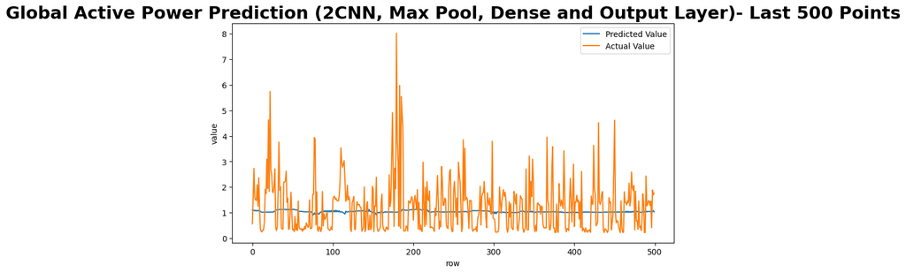

```python
# Make predictions
y_pred_test = model.predict(val_arrays)
y_true_test = val_labs

# Save predictions to CSV
test_set = pd.DataFrame(y_pred_test)
test_set.to_csv('submit_test.csv', index=None)

# Plot the predicted data vs. the actual data
fig_verify = plt.figure(figsize=(10, 5))
plt.plot(y_pred_test[-500:], label='Predicted Value')
plt.plot(y_true_test[-500:], label='Actual Value')
plt.title('Global Active Power Prediction (2CNN, Max Pool, Dense and Output Layer)- Last 500 Points', fontsize=22, fontweight='bold')
plt.ylabel('value')
plt.xlabel('row')
plt.legend()
plt.show()
fig_verify.savefig("model_regression_verify.png")
```

```python
#  play with your ideas for optimization here
# III. Change sequence_length to 50 (from 30)

df = pd.read_csv(file_path, parse_dates=['Datetime'])

# Display the first few rows of the DataFrame to verify it loaded correctly
print(df.head())

#create training and validation sets here
# Sort the data by Datetime to ensure it's in chronological order
df = df.sort_values('Datetime')

# Assign size for data subset (1% of the entire dataset)
subset_size = int(0.01 * len(df))

# Take random data subset
#n=subset_size: This argument specifies the number of rows needed in random subset.
#random_state=42: This is crucial for reproducibility.  It sets the seed for the random number generator.
#         Incase this code is run multiple times with the same random_state, this will result in getting the same random subset which is important for testing,
#         debugging, and sharing results.  IF this argument is None, then the same subset is not got every time
df_subset = df.sample(n=subset_size, random_state=42)

# Sort the subset by Datetime again to maintain chronological order
df_subset = df_subset.sort_values('Datetime')

# Split data subset 80/20 for train/validation
# Split the df_subset which is a random sample of the original DataFrame, its index still reflects the original time order into training and validation sets.
# We use the index to split to maintain the time order
#len(df_subset): Gets the number of rows in the df_subset.
#0.8 * len(df_subset): Calculates 80% of the number of rows. This determines the split point between training and validation sets.
#int(...): Converts the result to an integer. This is necessary because slice indices must be integers. This effectively truncates any decimal portion, so the training set might be slightly smaller than 80% if the total number of rows isn't perfectly divisible by 5.
#split_index: Stores the calculated index value. This index marks the boundary between the training and validation sets.

split_index = int(0.8 * len(df_subset))


# This creates the training set. It takes all rows from df_subset up to (but not including) the row at split_index.
# Because the original index from the dataframe is used, and because the subset was randomly selected while maintaining the original time order via the index,
# this subset will maintain the time order.
# train_df: Stores the resulting training DataFrame

train_df = df_subset[:split_index]

# Create the validation set. It takes all rows from df_subset starting from the row at split_index to the end of the DataFrame.
val_df = df_subset[split_index:]


#reset the indices for cleanliness
#After splitting the data, the original index from the full dataset is retained. Resetting the index ensures that both train_df and val_df have a clean, continuous index starting from 0.
#This makes it easier to work with the data, especially when iterating over rows or accessing specific entries by index.
train_df = train_df.reset_index()
val_df = val_df.reset_index()

print(f"Training set shape: {train_df.shape}")
print(f"Validation set shape: {val_df.shape}")

# show me how one or two of your different models perform
# using the code from the "Validating our model" section above

seq_arrays = []
seq_labs = []
import numpy as np

# Get GAP readings from your DataFrame column
gap_readings = train_df['Global_active_power'].values  # Direct numpy array access

#use 30 consecutive measurements to predict value 5 steps in future
seq_length = 50  # 50-minute window
ph = 5        # Predict 5 minutes ahead
feat_cols = ['Global_active_power']  # Define feature columns

# Create sequences with alignment for predictive horizon
seq_arrays = []
seq_labs = []

# Calculate valid range for sequence creation

# Total Data Points: len(gap_readings) = 16,359 historical GAP measurements.
#Sequence Length: Each input sequence uses 30 consecutive measurements.
#Predictive Horizon:  To predict the GAP value 5 steps ahead of the input sequence.
#Input Sequence: Each sequence starts at index i and ends at i + seq_length - 1.
#Output Value: Predicted value is at index i + seq_length + ph - 1.
#Last Valid Sequence:
#Start index i must satisfy:
#i + seq_length + ph - 1 < len(gap_readings)
#For the dataset with len = 16359:
# i + 30 + 5 - 1 < 16,359 → i < 16,359 - 34 → i ≤ 16,324
# Total sequences: 16,325 (i ranges from 0 to 16,324).

num_samples = len(gap_readings) - seq_length - ph + 1

#Sequence creation loop
#Input Sequence: Sliding window of 30 consecutive values
#Output Value: Value 5 steps after the end of the input window

for i in range(num_samples):
    # Input: 30 consecutive GAP measurements
    input_seq = gap_readings[i:i+seq_length]

    # Output: GAP value 5 cycles after sequence end
    output_val = gap_readings[i + seq_length + ph - 1]

    # append(input_seq): adds the current input_seq (which is itself a sequence of data points) to the end of the seq_arrays list.
    # So, seq_arrays will become a list of lists (or a list of arrays).
    #input_seq is a sequence of 30 consecutive GAP measurements (because seq_length = 30).
    #seq_arrays is a list that will contain all these sequences.
    #.append() adds input_seq as a new element to the end of seq_arrays.
    #After this operation, seq_arrays becomes a list of lists, where each inner list is a sequence of 30 GAP measurements.
    # Example:
    # seq_arrays = [
    # [0.5, 0.6, ..., 0.8],  # First sequence (30 values)
    # [0.6, 0.7, ..., 0.9],  # Second sequence (30 values)
    # ...
    seq_arrays.append(input_seq) #store the input sequence of time series data in numpy array

    # add the output_val to the seq_labs list
    # output_val is a single GAP measurement, 5 steps ahead of the end of the input sequence.
    # seq_labs is a list that will contain all these future values.
    # append(): This adds output_val as a new element to the end of seq_labs.
    # After this operation, seq_labs becomes a list of individual GAP values, each corresponding to the future value for its respective input sequence.
    # Example:
    # python
    # seq_labs = [0.7, 0.8, 0.9, ...]  # Each value corresponds to a sequence in seq_arrays
    seq_labs.append(output_val)
```

```python
# Convert to numpy arrays with proper typing
seq_arrays = np.array(seq_arrays, dtype=np.float32).reshape(-1, seq_length, len(feat_cols))
seq_labs = np.array(seq_labs, dtype=np.float32)

print("Input shape:", seq_arrays.shape)
print("Output shape:", seq_labs.shape)

# Verify dimensions with corrected calculation
expected_samples = len(train_df) - seq_length - ph + 1
expected_shape = (expected_samples, seq_length, len(feat_cols))

try:
    assert seq_arrays.shape == expected_shape, (
    f"Sequence array shape mismatch. Got {seq_arrays.shape}, "
    f"expected {expected_shape}. Check data length: {len(train_df)} "
    f"should be ≥ {seq_length + ph}"
)

    assert seq_labs.shape == (expected_samples,), (
    f"Label shape mismatch. Got {seq_labs.shape}, "
    f"expected ({expected_samples},)"

)
    print("All assertions passed!")
except AssertionError as e:
    print(f"Assertion Error: {e}")
    print(f"Required data length: {seq_length + ph - 1}")
    print(f"Actual data length: {len(train_df)}")

assert(seq_arrays.shape == (len(train_df)-seq_length-ph+1,seq_length, len(feat_cols)))
assert(seq_labs.shape == (len(train_df)-seq_length-ph+1,))
# define path to save model
model_path = 'LSTM_model1.keras'

# build the network
# Onfe Feature which is GAP and one Output value (GAP) is predicted
nb_features = 1
nb_out = 1

# Initialize a Sequential model
model = Sequential()
model.add(Input(shape=(seq_length, nb_features)))  # (30, 1) based on our sequence creation
model.add(LSTM(units=5, return_sequences=True)) # Number of LSTM units (neurons) in this layer

#add first LSTM layer
model.add(Dropout(0.2)) # Return full sequence for next LSTM layer

# add second LSTM layer
model.add(LSTM(
          units=3,  #number of LSTM units in this layer 2 of LSTM
          return_sequences=False)) # do not return
# Add dropout for regularization
model.add(Dropout(0.2))

# Add Dense (fully connected) output layer
model.add(Dense(units=nb_out))  # Output layer with 1 unit for regression
model.add(Activation("linear"))  # Linear activation for regression

# Define optimizer with learning rate
optimizer = keras.optimizers.Adam(learning_rate = 0.01)

#Loss function is MSE, Adam optimizer, track MSE durig trainig
# uses Mean Squared Error as both the loss function and a metric, appropriate for regression tasks.
model.compile(loss='mean_squared_error', optimizer=optimizer, metrics=['mse'])

print(model.summary())

# fit the network (train it)
# max number of trainig epochs = 100
# number of samples per gradient update (batch size) = 500
# use 5% of data for validation
# verbosity mode = 2, one line per epoch
# callback - early stopping to prevent overfitting and if no more learnig is happening
#  monitor='val_loss',  # Monitor validation loss
# min_delta=0:  Minimum change to qualify as improvement
# patience=10:  Number of epochs with no improvement after which training will stop
# verbose=0:  Verbosity mode
# mode='min'  # The direction is automatically inferred if not set

# Model checkpoint to save best model
# model_path,  # Path to save the model
# monitor='val_loss',  # Monitor validation loss
# save_best_only=True,  # Only save when the model is better than the previous best
# mode='min',  # Lower validation loss is better
#verbose=0  # Verbosity mode

history = model.fit(seq_arrays, seq_labs, epochs=100, batch_size=500, validation_split=0.05, verbose=2,
          callbacks = [keras.callbacks.EarlyStopping(monitor='val_loss', min_delta=0, patience=10, verbose=0, mode='min'),
                       keras.callbacks.ModelCheckpoint(model_path,monitor='val_loss', save_best_only=True, mode='min', verbose=0)]
          )

# list all data in history
# After training, it prints the keys of the history object, which typically include 'loss', 'mse', 'val_loss', and 'val_mse', representing the training and validation metrics over epochs.
print(history.history.keys())

# show me how one or two of your different models perform
# using the code from the "Validating our model" section above

val_arrays = []
val_labs = []

# Create sequences starting with minimum of 2 readings, building up to seq_length
for i in range(2, len(val_df['Global_active_power'])):
    # Get all available readings up to current index
    raw_seq = val_df['Global_active_power'].values[:i]  # Get readings from start to current position

    # Get label (ph steps ahead)
    if i + ph - 1 < len(val_df):  # Check if we have enough data for the label
        val_labs.append(val_df['Global_active_power'].values[i + ph - 1])
    else:  # Handle edge case at end of dataset
        break

    val_arrays.append(raw_seq)

# Pad sequences to uniform length (seq_length) with pre-padding (zeros at beginning)
val_arrays = pad_sequences(
    val_arrays,
    maxlen=seq_length,  # Force all sequences to be seq_length long
    dtype='float32',     # Match TensorFlow's default dtype
    padding='pre',       # Add zeros at BEGINNING of sequences (preserve recent data)
    truncating='pre',    # Truncate from beginning if sequences are too long (shouldn't happen here)
    value=0              # Use 0 for padding (consider using mean value if better for your data)
)

# Convert labels to numpy array with proper dtype
val_labs = np.array(val_labs, dtype=np.float32)

print("Padded validation sequences shape:", val_arrays.shape)
print("Validation labels shape:", val_labs.shape)

# Reshape val_arrays to add the feature dimension
val_arrays = np.reshape(val_arrays, (val_arrays.shape[0], val_arrays.shape[1], nb_features))

# Ensure val_labs is a 1D array
val_labs = np.reshape(val_labs, (-1,))

# Debugging: Print shapes
print("Shape of val_arrays:", val_arrays.shape)
print("Shape of val_labs:", val_labs.shape)

# Evaluate the model
scores_test = model.evaluate(val_arrays, val_labs, verbose=2)
print('\nMSE: {}'.format(scores_test[1]))

# Make predictions
y_pred_test = model.predict(val_arrays)
y_true_test = val_labs

# Save predictions to CSV
test_set = pd.DataFrame(y_pred_test)
test_set.to_csv('submit_test.csv', index=None)
```

```
   Unnamed: 0        Date      Time  Global_active_power  \
0           0  2006-12-16  17:24:00                4.216
1           1  2006-12-16  17:25:00                5.360
2           2  2006-12-16  17:26:00                5.374
3           3  2006-12-16  17:27:00                5.388
4           4  2006-12-16  17:28:00                3.666

   Global_reactive_power  Voltage  Global_intensity  Sub_metering_1  \
0                  0.418   234.84              18.4             0.0
1                  0.436   233.63              23.0             0.0
2                  0.498   233.29              23.0             0.0
3                  0.502   233.74              23.0             0.0
4                  0.528   235.68              15.8             0.0

   Sub_metering_2  Sub_metering_3            Datetime  gap_monthly  \
0             1.0            17.0 2006-12-16 17:24:00          NaN
1             1.0            16.0 2006-12-16 17:25:00          NaN
2             2.0            17.0 2006-12-16 17:26:00          NaN
3             1.0            17.0 2006-12-16 17:27:00          NaN
4             1.0            17.0 2006-12-16 17:28:00          NaN

   grp_monthly  v_monthly  gi_monthly
0          NaN        NaN         NaN
1          NaN        NaN         NaN
2          NaN        NaN         NaN
3          NaN        NaN         NaN
4          NaN        NaN         NaN
Training set shape: (16393, 16)
Validation set shape: (4099, 16)
Input shape: (16339, 50, 1)
Output shape: (16339,)
All assertions passed!
```

```
Model: "sequential_27"
```

```
┏━━━━━━━━━━━━━━━━━━━━━━━━━━━━━━━━━━━━━━┳━━━━━━━━━━━━━━━━━━━━━━━━━━━━━┳━━━━━━━━━━━━━━━━━┓
┃ Layer (type)                         ┃ Output Shape                ┃         Param # ┃
┡━━━━━━━━━━━━━━━━━━━━━━━━━━━━━━━━━━━━━━╇━━━━━━━━━━━━━━━━━━━━━━━━━━━━━╇━━━━━━━━━━━━━━━━━┩
│ lstm_44 (LSTM)                       │ (None, 50, 5)               │             140 │
├──────────────────────────────────────┼─────────────────────────────┼─────────────────┤
│ dropout_61 (Dropout)                 │ (None, 50, 5)               │               0 │
├──────────────────────────────────────┼─────────────────────────────┼─────────────────┤
│ lstm_45 (LSTM)                       │ (None, 3)                   │             108 │
├──────────────────────────────────────┼─────────────────────────────┼─────────────────┤
│ dropout_62 (Dropout)                 │ (None, 3)                   │               0 │
├──────────────────────────────────────┼─────────────────────────────┼─────────────────┤
│ dense_28 (Dense)                     │ (None, 1)                   │               4 │
├──────────────────────────────────────┼─────────────────────────────┼─────────────────┤
│ activation_11 (Activation)           │ (None, 1)                   │               0 │
└──────────────────────────────────────┴─────────────────────────────┴─────────────────┘
```

```
 Total params: 252 (1008.00 B)
```

```
 Trainable params: 252 (1008.00 B)
```

```
 Non-trainable params: 0 (0.00 B)
```

```
None
32/32 - 5s - 160ms/step - loss: 1.5139 - mse: 1.5139 - val_loss: 1.6885 - val_mse: 1.6885
32/32 - 1s - 45ms/step - loss: 1.2132 - mse: 1.2132 - val_loss: 1.5449 - val_mse: 1.5449
32/32 - 1s - 44ms/step - loss: 1.1881 - mse: 1.1881 - val_loss: 1.5307 - val_mse: 1.5307
32/32 - 2s - 66ms/step - loss: 1.1654 - mse: 1.1654 - val_loss: 1.5127 - val_mse: 1.5127
32/32 - 2s - 72ms/step - loss: 1.1634 - mse: 1.1634 - val_loss: 1.4895 - val_mse: 1.4895
32/32 - 2s - 54ms/step - loss: 1.1559 - mse: 1.1559 - val_loss: 1.4858 - val_mse: 1.4858
32/32 - 3s - 78ms/step - loss: 1.1440 - mse: 1.1440 - val_loss: 1.4896 - val_mse: 1.4896
32/32 - 3s - 79ms/step - loss: 1.1346 - mse: 1.1346 - val_loss: 1.4820 - val_mse: 1.4820
32/32 - 3s - 80ms/step - loss: 1.1254 - mse: 1.1254 - val_loss: 1.4723 - val_mse: 1.4723
32/32 - 2s - 49ms/step - loss: 1.1295 - mse: 1.1295 - val_loss: 1.4912 - val_mse: 1.4912
32/32 - 3s - 105ms/step - loss: 1.1223 - mse: 1.1223 - val_loss: 1.4614 - val_mse: 1.4614
32/32 - 1s - 46ms/step - loss: 1.1172 - mse: 1.1172 - val_loss: 1.4522 - val_mse: 1.4522
32/32 - 1s - 43ms/step - loss: 1.1193 - mse: 1.1193 - val_loss: 1.4584 - val_mse: 1.4584
32/32 - 1s - 44ms/step - loss: 1.1154 - mse: 1.1154 - val_loss: 1.4835 - val_mse: 1.4835
32/32 - 1s - 44ms/step - loss: 1.1140 - mse: 1.1140 - val_loss: 1.4653 - val_mse: 1.4653
32/32 - 3s - 79ms/step - loss: 1.1159 - mse: 1.1159 - val_loss: 1.4403 - val_mse: 1.4403
32/32 - 3s - 89ms/step - loss: 1.1445 - mse: 1.1445 - val_loss: 1.5281 - val_mse: 1.5281
32/32 - 3s - 98ms/step - loss: 1.1137 - mse: 1.1137 - val_loss: 1.4592 - val_mse: 1.4592
32/32 - 2s - 52ms/step - loss: 1.1103 - mse: 1.1103 - val_loss: 1.4641 - val_mse: 1.4641
32/32 - 2s - 78ms/step - loss: 1.1109 - mse: 1.1109 - val_loss: 1.4588 - val_mse: 1.4588
32/32 - 3s - 80ms/step - loss: 1.1120 - mse: 1.1120 - val_loss: 1.4535 - val_mse: 1.4535
32/32 - 1s - 44ms/step - loss: 1.1115 - mse: 1.1115 - val_loss: 1.4675 - val_mse: 1.4675
32/32 - 3s - 87ms/step - loss: 1.1141 - mse: 1.1141 - val_loss: 1.4597 - val_mse: 1.4597
32/32 - 3s - 100ms/step - loss: 1.1083 - mse: 1.1083 - val_loss: 1.4548 - val_mse: 1.4548
32/32 - 2s - 52ms/step - loss: 1.1096 - mse: 1.1096 - val_loss: 1.4570 - val_mse: 1.4570
32/32 - 2s - 72ms/step - loss: 1.1117 - mse: 1.1117 - val_loss: 1.4663 - val_mse: 1.4663
dict_keys(['loss', 'mse', 'val_loss', 'val_mse'])
Padded validation sequences shape: (4093, 50)
Validation labels shape: (4093,)
Shape of val_arrays: (4093, 50, 1)
Shape of val_labs: (4093,)
128/128 - 1s - 7ms/step - loss: 0.8302 - mse: 0.8302

MSE: 0.830170214176178
128/128 ━━━━━━━━━━━━━━━━━━━━ 1s 9ms/step
```

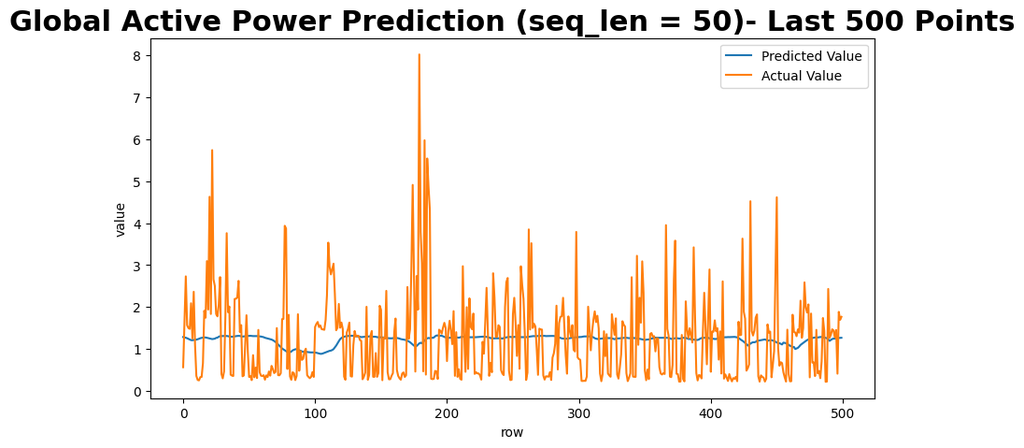

```python
# Plot the predicted data vs. the actual data
fig_verify = plt.figure(figsize=(10, 5))
plt.plot(y_pred_test[-500:], label='Predicted Value')
plt.plot(y_true_test[-500:], label='Actual Value')
plt.title('Global Active Power Prediction (seq_len = 50)- Last 500 Points', fontsize=22, fontweight='bold')
plt.ylabel('value')
plt.xlabel('row')
plt.legend()
plt.show()
fig_verify.savefig("model_regression_verify.png")
```

```
32/32 - 9s - 268ms/step - loss: 1.2329 - mse: 1.2329 - val_loss: 1.6376 - val_mse: 1.6376
32/32 - 3s - 81ms/step - loss: 1.1805 - mse: 1.1805 - val_loss: 1.7246 - val_mse: 1.7246
32/32 - 5s - 167ms/step - loss: 1.1849 - mse: 1.1849 - val_loss: 1.7277 - val_mse: 1.7277
32/32 - 3s - 82ms/step - loss: 1.1775 - mse: 1.1775 - val_loss: 1.6575 - val_mse: 1.6575
32/32 - 5s - 151ms/step - loss: 1.1778 - mse: 1.1778 - val_loss: 1.5736 - val_mse: 1.5736
32/32 - 3s - 80ms/step - loss: 1.1790 - mse: 1.1790 - val_loss: 1.6097 - val_mse: 1.6097
32/32 - 4s - 124ms/step - loss: 1.1752 - mse: 1.1752 - val_loss: 1.7110 - val_mse: 1.7110
32/32 - 3s - 108ms/step - loss: 1.1745 - mse: 1.1745 - val_loss: 1.6903 - val_mse: 1.6903
32/32 - 2s - 71ms/step - loss: 1.1705 - mse: 1.1705 - val_loss: 1.6477 - val_mse: 1.6477
32/32 - 3s - 79ms/step - loss: 1.1709 - mse: 1.1709 - val_loss: 1.6418 - val_mse: 1.6418
32/32 - 2s - 75ms/step - loss: 1.1695 - mse: 1.1695 - val_loss: 1.6102 - val_mse: 1.6102
32/32 - 4s - 125ms/step - loss: 1.1699 - mse: 1.1699 - val_loss: 1.7404 - val_mse: 1.7404
32/32 - 3s - 106ms/step - loss: 1.1734 - mse: 1.1734 - val_loss: 1.5982 - val_mse: 1.5982
32/32 - 3s - 80ms/step - loss: 1.1705 - mse: 1.1705 - val_loss: 1.6517 - val_mse: 1.6517
32/32 - 2s - 72ms/step - loss: 1.1703 - mse: 1.1703 - val_loss: 1.6481 - val_mse: 1.6481
128/128 - 1s - 8ms/step - loss: 0.8545 - mse: 0.8545
MSE: 0.8545377254486084
128/128 ━━━━━━━━━━━━━━━━━━━━ 2s 11ms/step
```

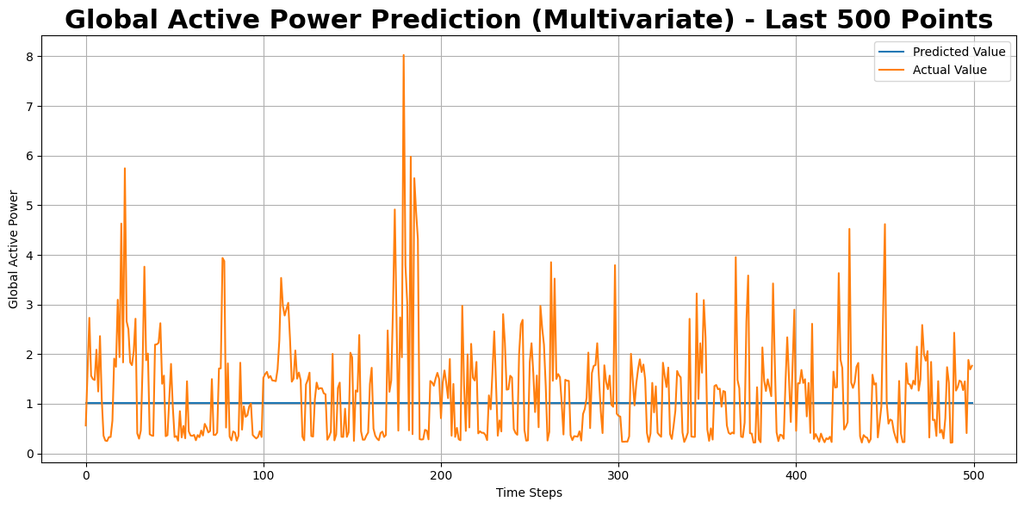

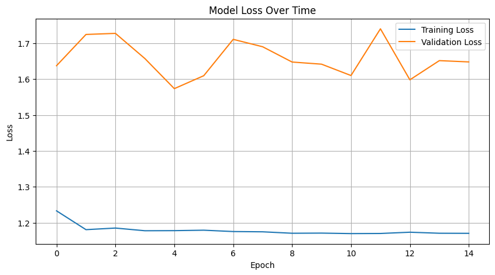

```python
# play with your ideas for optimization here
# IV Model change - Adding Multivariate (Voltage, Global Intensity and Global Reactive power) as Dependent variables

# Load data
df = pd.read_csv('/content/drive/MyDrive/AAI-530-DataAnalyticsAndIOT/household_power_clean.csv', parse_dates=['Datetime'])

# Data preprocessing
df = df.sort_values('Datetime')
subset_size = int(0.01 * len(df))
df_subset = df.sample(n=subset_size, random_state=42).sort_values('Datetime')
split_index = int(0.8 * len(df_subset))
train_df = df_subset[:split_index].reset_index()
val_df = df_subset[split_index:].reset_index()

# Define feature columns
feat_cols = ['Global_active_power', 'Voltage', 'Global_intensity', 'Global_reactive_power']

# Sequence creation with multiple features
seq_length = 30
ph = 5
num_samples = len(train_df) - seq_length - ph + 1

# show me how one or two of your different models perform
# using the code from the "Validating our model" section above
seq_arrays = []
seq_labs = []

for i in range(num_samples):
    input_seq = train_df[feat_cols].values[i:i+seq_length]
    output_val = train_df['Global_active_power'].values[i + seq_length + ph - 1]
    seq_arrays.append(input_seq)
    seq_labs.append(output_val)

seq_arrays = np.array(seq_arrays, dtype=np.float32)
seq_labs = np.array(seq_labs, dtype=np.float32)

# Model building
model_path = 'LSTM_model_multivariate.keras'
nb_features = len(feat_cols)
nb_out = 1

model = Sequential()

model.add(Input(shape=(seq_length, nb_features)))  # Explicit input layer
model.add(LSTM(units=32, return_sequences=True))
model.add(Dropout(0.2))

model.add(LSTM(units=16, return_sequences=False))
model.add(Dropout(0.2))
model.add(Dense(units=8, activation='relu'))
model.add(Dense(units=nb_out))
model.add(Activation("linear"))

optimizer = keras.optimizers.Adam(learning_rate=0.01)
model.compile(loss='mean_squared_error', optimizer=optimizer, metrics=['mse'])

# Model training
history = model.fit(
    seq_arrays, seq_labs,
    epochs=100,
    batch_size=500,
    validation_split=0.05,
    verbose=2,
    callbacks=[
        keras.callbacks.EarlyStopping(monitor='val_loss', patience=10, mode='min'),
        keras.callbacks.ModelCheckpoint(model_path, monitor='val_loss', save_best_only=True, mode='min')
    ]
)

# Validation data preparation
val_arrays = []
val_labs = []

for i in range(2, len(val_df)):
    if i + ph - 1 < len(val_df):
        raw_seq = val_df[feat_cols].values[:i]
        val_arrays.append(raw_seq)
        val_labs.append(val_df['Global_active_power'].values[i + ph - 1])

val_arrays = pad_sequences(val_arrays, maxlen=seq_length, dtype='float32', padding='pre', truncating='pre', value=0)
val_labs = np.array(val_labs, dtype=np.float32)
val_arrays = np.reshape(val_arrays, (val_arrays.shape[0], val_arrays.shape[1], nb_features))

# Model evaluation and prediction
scores_test = model.evaluate(val_arrays, val_labs, verbose=2)
print(f'MSE: {scores_test[1]}')
y_pred_test = model.predict(val_arrays)
y_true_test = val_labs

# Visualization
plt.figure(figsize=(12, 6))
plt.plot(y_pred_test[-500:], label='Predicted Value')
plt.plot(y_true_test[-500:], label='Actual Value')
plt.title('Global Active Power Prediction (Multivariate) - Last 500 Points',
          fontsize=22, fontweight='bold')
plt.ylabel('Global Active Power')
plt.xlabel('Time Steps')
plt.legend()
plt.grid(True)
plt.tight_layout()
plt.savefig("multivariate_model_prediction.png")
plt.show()

# Plot training history
plt.figure(figsize=(10, 5))
plt.plot(history.history['loss'], label='Training Loss')
plt.plot(history.history['val_loss'], label='Validation Loss')
plt.title('Model Loss Over Time')
plt.xlabel('Epoch')
plt.ylabel('Loss')
plt.legend()
plt.grid(True)
plt.savefig("training_history.png")
plt.show()
```

```
10247/10247 ━━━━━━━━━━━━━━━━━━━━ 4494s 438ms/step - loss: 0.3704 - mae: 0.2869 - val_loss: 0.2304 - val_mae: 0.2445
10247/10247 ━━━━━━━━━━━━━━━━━━━━ 4456s 435ms/step - loss: 0.2668 - mae: 0.2540 - val_loss: 0.2272 - val_mae: 0.2454

Test MSE: 0.1924, MAE: 0.2314
12808/12808 ━━━━━━━━━━━━━━━━━━━━ 697s 54ms/step
```

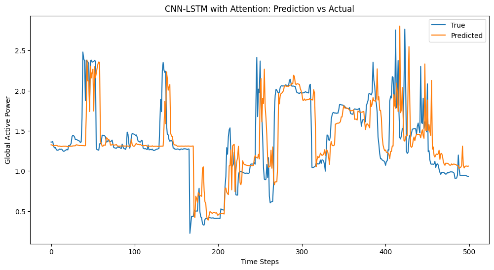

```python
# V. Architerctural change - CNN feature extraction, Bidirectional LSTM with attention mechanism, Temporal Pooling and output layer

import numpy as np
import pandas as pd
import matplotlib.pyplot as plt
from sklearn.preprocessing import MinMaxScaler
from tensorflow.keras.models import Model
from tensorflow.keras.layers import (Input, Conv1D, LSTM, Dense, Dropout,
                                   Bidirectional, LayerNormalization, Attention,
                                   concatenate)
from tensorflow.keras.optimizers import Adam
from tensorflow.keras.callbacks import EarlyStopping, ModelCheckpoint

# Mount Google Drive
from google.colab import drive
drive.mount('/content/drive')

# Load the dataset
file_path = '/content/drive/MyDrive/AAI-530-DataAnalyticsAndIOT/household_power_clean.csv'

df = pd.read_csv(file_path, parse_dates=['Datetime'])

# 1. Data Preparation Functions
def load_data(file_path):
    df = pd.read_csv(file_path, parse_dates=['Datetime'], index_col='Datetime')
    return df.sort_index()

def create_sequences(data, seq_length, pred_horizon):
    xs, ys = [], []
    for i in range(len(data)-seq_length-pred_horizon+1):
        x = data[i:(i+seq_length)]
        y = data[i+seq_length+pred_horizon-1]
        xs.append(x)
        ys.append(y)
    return np.array(xs), np.array(ys)

# 2. Enhanced Model Architecture
def build_cnn_lstm_attention(seq_length=30, n_features=1):
    inputs = Input(shape=(seq_length, n_features))

    # CNN Feature Extraction
    x = Conv1D(64, kernel_size=3, activation='relu', padding='same')(inputs)
    x = LayerNormalization()(x)
    x = Dropout(0.3)(x)

    # Bidirectional LSTM
    x = Bidirectional(LSTM(128, return_sequences=True))(x)

    # Attention Mechanism
    attention = Attention()([x, x])
    x = concatenate([x, attention])
    x = LayerNormalization()(x)
    x = Dropout(0.4)(x)

    # Temporal Pooling
    x = LSTM(64, return_sequences=False)(x)
    x = Dense(32, activation='relu', kernel_regularizer='l2')(x)

    # Output
    outputs = Dense(1)(x)

    return Model(inputs=inputs, outputs=outputs)

# 3. Training Configuration
def train_model(model, X_train, y_train):
    optimizer = Adam(learning_rate=0.001)
    model.compile(loss='mse', optimizer=optimizer, metrics=['mae'])

    callbacks = [
        EarlyStopping(monitor='val_loss', patience=15, restore_best_weights=True),
        ModelCheckpoint('best_model.keras', save_best_only=True)
    ]

    history = model.fit(
        X_train, y_train,
        epochs=2,
        batch_size=128,
        validation_split=0.2,
        callbacks=callbacks,
        verbose=1
    )
    return history

# 4. Main Workflow
if __name__ == "__main__":
    # Load and preprocess data
    #df = load_data('household_power_clean.csv')
    data = df[['Global_active_power']].values

    # Parameters
    SEQ_LENGTH = 30
    PRED_HORIZON = 5

    # Create sequences
    X, y = create_sequences(data, SEQ_LENGTH, PRED_HORIZON)
    X = X.reshape(-1, SEQ_LENGTH, 1)  # Add feature dimension

    # Train-test split
    split = int(0.8 * len(X))
    X_train, y_train = X[:split], y[:split]
    X_test, y_test = X[split:], y[split:]

    # Build and train model
    model = build_cnn_lstm_attention(SEQ_LENGTH)
    history = train_model(model, X_train, y_train)

    # Evaluate
    test_loss = model.evaluate(X_test, y_test, verbose=0)
    print(f"\nTest MSE: {test_loss[0]:.4f}, MAE: {test_loss[1]:.4f}")

    # Generate predictions
    y_pred = model.predict(X_test)

    # Visualization
    plt.figure(figsize=(12,6))
    plt.plot(y_test[-500:], label='True')
    plt.plot(y_pred[-500:], label='Predicted')
    plt.title("CNN-LSTM with Attention: Prediction vs Actual")
    plt.xlabel("Time Steps")
    plt.ylabel("Global Active Power")
    plt.legend()
    plt.show()
```

**Q: How did your model changes affect performance on the validation data? Why do you think they were/were not effective? If you were trying to optimize for production, what would you try next?**

Answer:

## II. OPTIMIZATION STEPS TO IMPROVE THE MODEL:

With the tests infering that Linear Regression model with Moving Average outperforms more complex models like LSTM and CNN-Bidirectional LSTM in terms of MSE (0.038), but lags in capturing peaks and low points of power consumption, the model to choose is the model with improved ability to capture non-linear patterns and temporal dependencies in the data.

# Selection of Hybrid Models:

1. Combining the Linear Regression model with a non-linear model (e.g., Random Forest, Gradient Boosting, or Neural Networks) to capture both linear and non-linear patterns could be tried.
2. Ensemble approach: Using an ensemble approach (e.g., stacking or weighted averaging) to combine predictions from multiple models.

## Advanced Time Series Models:

3. Below Time series models could be tried.

a. Prophet: A time series forecasting model developed by Facebook that handles seasonality, trends, and holidays well.

b. ARIMA/SARIMA: Traditional time series models that can capture seasonality and trends.

c. XGBoost/LightGBM: Gradient boosting models that can handle non-linear relationships and feature interactions.It can handle non-linear relationships and feature interactions, making it well-suited for capturing complex patterns.

It can incorporate temporal and seasonal features (e.g., time of day, day of week, month, festivals) effectively.

## Model Architecture Improvements

a. LSTM/GRU with Attention: Additon of an attention mechanism to LSTM/GRU models to focus on important time steps (e.g., peaks and low points).

b. Transformer for Time Series: Using a Transformer-based model with self-attention to capture long-term dependencies and seasonal patterns.

c.TCN (Temporal Convolutional Network): Using a TCN with dilated convolutions to capture long-term dependencies efficiently.

5 ## Hyperparameter Tuning Usage of tools like Grid Search, Random Search, or Bayesian Optimization to find the best hyperparameters for your models.

6. Focus on tuning:

   a. Learning rate, number of layers, number of units (for neural networks).

b. Window size, number of lags, and rolling statistics (for feature engineering).

7. Error Analysis

Analyzis of the residuals (errors) of the Linear Regression model to identify patterns (e.g., systematic underprediction during peaks).

**Q: How did the models that you built in this assignment compare to the linear regression model from last week? Think about model performance and other IoT device considerations; Which model would you choose to use in an IoT system that predicts GAP for a single household with a 5-minute predictive horizon, and why?**

Answer:

## 1. I MODELS BUILT IN THIS ASSIGNMENT and its performance:

# II. INFERENCE:

## COMPARISON OF MODELS WITH LINEAR REGRESSION MODEL:

The Linear Regression moving average based model has improved well when compared to the Prediction Horizon and Forgetting factor based model which I had built. The moving average (MA) model which is a common approach for analyzing and forecasting time series data.The model assumes that the current value is a linear combination of past errors. It smooths out short-term fluctuations and highlights longer-term trends in the data.The order q determines how many past error terms are considered. MA model uses past forecast errors (the difference between the actual value and the forecasted value) to predict the current value. It assumes that these past errors provide information about the current and future values giving it better performance compared to other models

Though the Liner Regression with moving average model performed better (MSE = 0.038), there was lag: at certain points (particularly in high peaks and low power), in the predicted power compared to the Actual power. This could be due to the model's inability to perfectly predict the timing of power changes.

## A. CNN Feature Extraction:

Convolutional Neural Networks (CNNs) are excellent at extracting spatial features from input data, such as images or sequences. This step helps in capturing important patterns and reducing the dimensionality of the input.

## B. Bidirectional LSTM with Attention Mechanism:

Long Short-Term Memory (LSTM) networks are a type of Recurrent Neural Network (RNN) that can capture long-term dependencies in sequential data. The bidirectional aspect means the model processes the sequence in both forward and backward directions, which can improve context understanding. The attention mechanism allows the model to focus on specific parts of the input sequence, enhancing its ability to capture relevant information.

## C. Temporal Pooling:

This step aggregates information over time, which can help in summarizing the sequence data and reducing the model's complexity.

## D. Output Layer:

This layer produces the final predictions based on the processed features from the previous layers.

Mean Squared Error (MSE) with 2 Epochs: MSE is a common loss function for regression tasks, measuring the average squared difference between predicted and actual values. Training for 2 epochs means the model has gone through the entire training dataset twice and the model could perform if iterated through more Epochs.

This model has comparitively low MSE and aligns with the high and low power consumption points with a lag which indicates that the model is not effective in predicting the power consumption before 5 minutes for a household.

## WHICH MODEL WOULD BE BEST TO BE CHOSEN IN AN IOT SYSTEM THAT PREDICTS GAP FOR A SINGLE HOUSEHOLD WITH 5 MINUTE PREDICTIVE HORIZON:

With the tests infering that Linear Regression model with Moving Average outperforms more complex models like LSTM and CNN-Bidirectional LSTM in terms of MSE (0.038), but lags in capturing peaks and low points of power consumption, the model to choose is the model with improved ability to capture non-linear patterns and temporal dependencies in the data.

## Selection of Hybrid Models:

1. Combining the Linear Regression model with a non-linear model (e.g., Random Forest, Gradient Boosting, or Neural Networks) to capture both linear and non-linear patterns could be tried.
2. Ensemble approach: Using an ensemble approach (e.g., stacking or weighted averaging) to combine predictions from multiple models.

## Advanced Time Series Models:

3. Below Time series models could be tried.

a. Prophet: A time series forecasting model developed by Facebook that handles seasonality, trends, and holidays well.

b. ARIMA/SARIMA: Traditional time series models that can capture seasonality and trends.

c. XGBoost/LightGBM: Gradient boosting models that can handle non-linear relationships and feature interactions.It can handle non-linear relationships and feature interactions, making it well-suited for capturing complex patterns.

It can incorporate temporal and seasonal features (e.g., time of day, day of week, month, festivals) effectively.

## 4. Model Architecture Improvements

## a. LSTM/GRU with Attention:

Additon of an attention mechanism to LSTM/GRU models to focus on important time steps (e.g., peaks and low points).

## b. Transformer for Time Series:

Using a Transformer-based model with self-attention to capture long-term dependencies and seasonal patterns.

## c.TCN (Temporal Convolutional Network):

Using a TCN with dilated convolutions to capture long-term dependencies efficiently.

## 5. Hyperparameter Tuning

Usage of tools like Grid Search, Random Search, or Bayesian Optimization to find the best hyperparameters for your models.

## 6. Focus on tuning:

a. Learning rate, number of layers, number of units (for neural networks).

b. Window size, number of lags, and rolling statistics (for feature engineering).

## 7. Error Analysis

Analyzis of the residuals (errors) of the Linear Regression model to identify patterns (e.g., systematic underprediction during peaks).